# Project Introduction

**[Department of Transportation's Responsibilities](https://www.google.com/search?client=safari&rls=en&q=department+of+transportation+responsibilities&ie=UTF-8&oe=UTF-8)**

## Resources:

- **[Kaggle-Full](https://www.kaggle.com/datasets/sobhanmoosavi/us-accidents/data)**
- **[Kaggle-Sampled](https://drive.google.com/file/d/1U3u8QYzLjnEaSurtZfSAS_oh9AT2Mn8X/edit)**
- **[Bing API](https://learn.microsoft.com/en-us/bingmaps/rest-services/traffic/get-traffic-incidents#supported-http-methods)**
- **[MQuest API](https://developer.mapquest.com/documentation/api/traffic/incidents/get.html)**
- **['A Countrywide Traffic Accident Dataset'](https://arxiv.org/pdf/1906.05409)**
- **['Accident Risk Prediction based on Heterogenous Sparse Data: New Dataset & Insights](https://arxiv.org/pdf/1909.09638)**
- **['Census Data'](https://www.census.gov/acs/www/data/data-tables-and-tools/subject-tables/)**

# 1-Setup Environment

## Libraries

```python
#Utilities
import warnings
import os

# Data Basics
import pandas as pd
import numpy as np
import missingno as msgno

#Time Data
from datetime import date, timedelta


#PySpark
from pyspark.sql import SparkSession
from pyspark.mllib.stat import Statistics
import pyspark.sql.functions as F

#Visuals
import matplotlib.pyplot as plt
import seaborn as sns


# Statistical Analysis
from scipy.stats import zscore, f_oneway, chi2_contingency, chisquare
import statsmodels.api as sm
from statsmodels.formula.api import ols
from sklearn.decomposition import PCA
from sklearn.cluster import KMeans
from sklearn.metrics import silhouette_score
from yellowbrick.cluster import KElbowVisualizer, SilhouetteVisualizer
from sklearn.preprocessing import StandardScaler, OneHotEncoder


# Spatial Tools
import geopy
import geopy.distance
import census
import requests

# Text Tools
import re
from wordcloud import WordCloud

from nltk.tokenize import word_tokenize, sent_tokenize
from nltk.corpus import stopwords, wordnet
from nltk.probability import FreqDist
from nltk.stem import PorterStemmer, WordNetLemmatizer
from nltk.util import ngrams
```

## Info on New Libraries

For improved analysis, these libraries were included, but not covered in the course material:

- **[Geopy:](https://geopy.readthedocs.io/en/stable/)**
- Census:
  - **[PyPi](https://pypi.org/project/census/)**
  - **[API](https://www.census.gov/data/developers/guidance/api-user-guide.html)**
- MissingNo:
  - **[Library](https://github.com/ResidentMario/missingno)**
  - **[Tutorial](https://www.geeksforgeeks.org/python-visualize-missing-values-nan-values-using-missingno-library/)**
- **[Yellowbrick](https://www.scikit-yb.org/en/latest/)**

## Settings

```python
pd.set_option('display.max_columns', None)
pd.set_option('display.float_format', lambda x: '%.3f' % x)
pd.set_option('display.width', 500)
_LITE_SWITCH_ = False
_SPARK_ = False
```

## Custom Functions

```python
# For High-level data exploration
def count_outliers(df_col,cap=3):
    zs = zscore(df_col)
    return df_col[zs > cap].shape[0]
```

```python
# For Identify Unusual Weather Pattern(s)
def unusual_weather(observation):
    flag = False
    return flag
```

```python
cities = {
            'NYC':('40.7128','74.0060'),
            'Chicago':('41.8781','87.6298'),
            'Miami':('25.7617','80.1918'),
            'Atlanta':('33.7501', '84.3885'),
            'Charlotte':('35.2216','80.8401'),
            'Dallas':('32.7767', '96.7970'),
            'Houston':('29.7601','95.3701'),
            'Denver': ('39.7392', '104.9903'),
            'LA':('34.0549', '118.2426'),
            'Seattle':('47.6061', '122.3328')
         }
def within_limits(event,city,radius=25):
    flag = False
    return flag

def distance_btwn_incidents(eventA,eventB):
    ptA = (str(eventA['Start_Lat']),str(eventA['Start_Lng']))
    ptB = (str(eventB['Start_Lat']),str(eventB['Start_Lng']))
def dist(pt_0,pt_1):
    return geopy.distance.distance(pt_0,pt_1).miles
```

```python
def highway_indicator(eventA):
    pass
```

```python
def same_road(eventA,eventB):
    indicator = False
    road_identifiers = ['Street','City','State','Zipcode']
    indicator = all(eventA[id]==eventB[id] for id in road_identifiers)
    return indicator
```

```python
# For indicating whether two events are close in space and, optionally, time.
def proximity_indicator(eventA,eventB,space_band=15,time_band=0):
    flag = False
    distance = dist(eventA[['longitude','latitude']],eventB[['longitude','latitude']])
    if (time_band > 0):
        time_lapse = abs(eventA['time']-eventB['time'])
        flag = bool((space_band > distance) and (time_band > time_lapse))
    else:
        flag = bool(space_band > distance)
    return flag
```

https://pandas.pydata.org/docs/reference/api/pandas.Period.days_in_month.html

https://www.google.com/search?client=safari&rls=en&q=number+of+mondays+in+period+python&ie=UTF-8&oe=UTF-8

Number of Mondays, Tuesdays, etc. 'D'

Number of days in the months, 'M'

Number of days in the quarters, 'Q'

Number of days in the years, 'Y'

Number of Holidays, 'Holiday'

Number of Weekdays/Weekends 'W'

```python
def get_days(period_type,period):
    pass

def get_number_days(start_date,end_date,conditional):
    pass
```

```python
# Holiday Indicators
# Given by Google:
def calculate_memorial_day(year):
    # Get the last day of May
    last_day_of_may = date(year, 5, 31)

    # Get the weekday of the last day of May (0=Monday, 6=Sunday)
    weekday = last_day_of_may.weekday()

    # Calculate the offset to get to the last Monday
    offset = (weekday - 0) % 7

    # Calculate Memorial Day
    memorial_day = last_day_of_may - timedelta(days=offset)

    return memorial_day

# Given by Google:
def get_thanksgiving_date(year):
    # Get the first day of November
    first_november = date(year, 11, 1)

    # Calculate the day of the week for the first of November (0 = Monday, 6 = Sunday)
    first_day_weekday = first_november.weekday()

    # Calculate the number of days to add to get to the first Thursday
    days_to_first_thursday = (3 - first_day_weekday) % 7

    # Calculate the date of the first Thursday of November
    first_thursday = first_november + timedelta(days=days_to_first_thursday)

    # Add 3 weeks (21 days) to get to the fourth Thursday (Thanksgiving)
    thanksgiving_date = first_thursday + timedelta(days=21)

    return thanksgiving_date

def get_labor_day(year):
    first = date(year,9,1)
    d = first
    while d.weekday() > 0:
       d = d + timedelta(days=1)
    return d
```

```python
def test_category(feature_name,dataset):
    # Time of Impact--ANOVA
    model_time = ols(f"Q('Time_of_Impact(hr)') ~ C({feature_name})", data=dataset).fit()
    anova_table_time = sm.stats.anova_lm(model_time, typ=2)
    # Distance of Impact--ANOVA
    model_distance = ols(f"Q('Distance(mi)') ~ C({feature_name})", data=dataset).fit()
    anova_table_distance = sm.stats.anova_lm(model_distance, typ=2)
    # Severity Distribution--ANOVA
    contingency_table = pd.crosstab(dataset[feature_name], dataset['Severity'])
    chi_results = chi2_contingency(contingency_table)
    return anova_table_time, anova_table_distance, chi_results

def display_categories(feature_name,dataset):
    plt.figure(figsize=(12, 6))
    plt.subplot(1, 2, 1)
    #sns.boxplot(x=feature_name, y='Severity', data=dataset, palette='viridis')
    sns.boxplot(hue=feature_name, y='Severity', data=dataset, palette='viridis')
    plt.title('Accident Severity by '+feature_name)
    plt.subplot(1, 2, 2)
    dataset[feature_name].value_counts().plot(kind='bar', color='skyblue')
    plt.title('Total Accidents by '+feature_name)
    plt.tight_layout()
    plt.show()
    pass
```

```python
def test_results(feature_name,dataset,alpha=0.975,visuals=True):
    anova_time,anova_distance,chi_test= test_category(feature_name,dataset)
    p_vals = dict()
    p_vals['time'] = ('ANOVA',anova_time['PR(>F)'].iloc[0])
    p_vals['distance'] = ('ANOVA', anova_distance['PR(>F)'].iloc[0])
    p_vals['severity'] = ('CHI-Squared', chi_test[1])

    test_results = []
    for topic, p_val in p_vals.items():
        msg = f"Based on the {p_val[0]} test's p-value of {p_val[1]}, "
        null_hypo = f"the null hypothesis that there is no significant difference in incident {topic}"
        null_hypo += f" across different {feature_name}s."
        if (1 - alpha) > p_val[1]:
            msg += f"we reject " + null_hypo
        else:
            msg += f"we fail to reject " + null_hypo
        print(msg)
        test_results.append(msg)
    if visuals:
        display_categories(feature_name=feature_name,dataset=dataset)
    return test_results, [anova_time,anova_distance,chi_test]
```

```python
def census_data(yr,state_county=False):
    base_link = f'https://api.census.gov/data/{yr}/acs/acs1?get=group(B08301)&ucgid=pseudo(0100000US$0400000)'
    #base_link = f'https://api.census.gov/data/{yr}/acs/acs5/subject?'
    if state_county:
        add_on = f'get=group(B08301)&POPGROUP=001&ucgid=pseudo(0100000US$0500000)'
    else:
        add_on = f''
        #add_on = f'get=group(B08301)&ucgid=pseudo(0100000US$0400000)'

    census_link = base_link + add_on

    r = requests.get(census_link)
    df = pd.DataFrame(r.json())
    df.columns = df.iloc[0]
    df = df.drop(0)
    df = df.set_index('NAME')
    columns = [c for c in df.columns if c.endswith('E')]
    df = df[columns]
    col_names = ['Total','Car_Truck_Van',
                'DriveAlone',
                'Carpool','2Person_Pool','3Person_Pool','4Person_Pool','56Person_Pool','7UpPerson_Pool',
                'Public','Bus','Subway','LongDistanceRail','LightRail','Ferry',
                'Taxi','Motorcycle','Bicycle','Walked','Other','WorkFromHome'
                ]

    df.columns = col_names
    df = df.astype(int)
    df[col_names] = df[col_names].apply(lambda r:r/r['Total'],axis=1)
    columns_filtered = ['DriveAlone','Carpool','Bus','Subway','LongDistanceRail','LightRail',
                        'Ferry','Taxi','Motorcycle','Bicycle','Walked','Other','WorkFromHome']
    return df[columns_filtered]
```

## Load Dataset(s)

For purposes of data exploration, want to have option to use lite version of the target dataset.

```python
if _SPARK_:
    spark = SparkSession.builder.appName("Accident Data Project").getOrCreate()
    data = spark.read.csv('US_Accidents_March23.csv',header=True,inferSchema=True)
else:
    if _LITE_SWITCH_:
        data = pd.read_csv('US_Accidents_March23_sampled_500k.csv')
    else:
        data = pd.read_csv('US_Accidents_March23.csv')
```

Also, want to upload some commuting data sourced from the census.

```python
commute_options = ['NAME','Year','DriveAlone','Carpool','Bus','Subway','LongDistanceRail','LightRail','Taxi','Motorcycle','Bicycle','Walked','Other','WorkFromHome']
all_commutes = pd.DataFrame(columns=commute_options)
for yr in range(2016,2024):
    if(os.path.exists(f'Commute_{yr}.csv')):
        commute_census = pd.read_csv(f'Commute_{yr}.csv')
    else:
        try:
            commute_census = census_data(yr)
        except:
            commute_census = census_data(yr-1)
        commute_census.to_csv(f'Commute_{yr}.csv')
    commute_census['Year'] = yr

    all_commutes = pd.concat([all_commutes,commute_census],axis=0)
```

```python
all_commutes
```

|  | NAME | Year | DriveAlone | Carpool | Bus | Subway | LongDistanceRail | LightRail | Taxi | Motorcycle | Bicycle | Walked | Other | WorkFromHome | Ferry |
| --- | --- | --- | --- | --- | --- | --- | --- | --- | --- | --- | --- | --- | --- | --- | --- |
| 0 | Alabama | 2016 | 0.861 | 0.080 | 0.003 | 0.000 | 0.000 | 0.000 | 0.001 | 0.001 | 0.001 | 0.012 | 0.007 | 0.033 | 0.000 |
| 1 | Alaska | 2016 | 0.690 | 0.122 | 0.011 | 0.000 | 0.000 | 0.000 | 0.002 | 0.001 | 0.010 | 0.076 | 0.035 | 0.052 | 0.000 |
| 2 | Arizona | 2016 | 0.765 | 0.110 | 0.017 | 0.001 | 0.000 | 0.000 | 0.001 | 0.004 | 0.008 | 0.018 | 0.012 | 0.063 | 0.000 |
| 3 | Arkansas | 2016 | 0.831 | 0.102 | 0.003 | 0.000 | 0.000 | 0.000 | 0.001 | 0.002 | 0.001 | 0.020 | 0.007 | 0.032 | 0.000 |
| 4 | California | 2016 | 0.736 | 0.103 | 0.033 | 0.001 | 0.012 | 0.005 | 0.001 | 0.003 | 0.010 | 0.027 | 0.011 | 0.058 | 0.001 |
| ... | ... | ... | ... | ... | ... | ... | ... | ... | ... | ... | ... | ... | ... | ... | ... |
| 47 | Washington | 2023 | 0.649 | 0.089 | 0.031 | 0.001 | 0.001 | 0.004 | 0.001 | 0.002 | 0.007 | 0.031 | 0.009 | 0.173 | 0.002 |
| 48 | West Virginia | 2023 | 0.776 | 0.098 | 0.005 | 0.000 | 0.000 | 0.000 | 0.002 | 0.001 | 0.001 | 0.023 | 0.011 | 0.083 | 0.000 |
| 49 | Wisconsin | 2023 | 0.749 | 0.076 | 0.011 | 0.000 | 0.000 | 0.000 | 0.001 | 0.001 | 0.005 | 0.026 | 0.008 | 0.122 | 0.000 |
| 50 | Wyoming | 2023 | 0.728 | 0.105 | 0.010 | 0.000 | 0.000 | 0.000 | 0.001 | 0.001 | 0.009 | 0.034 | 0.009 | 0.102 | 0.001 |
| 51 | Puerto Rico | 2023 | 0.831 | 0.068 | 0.007 | 0.002 | 0.000 | 0.002 | 0.001 | 0.001 | 0.001 | 0.023 | 0.013 | 0.051 | 0.001 |

416 rows × 15 columns

# 2-Initial EDA

## Schema & Feature Basics

```python
if _SPARK_:
    data.printSchema()
    print("Features: ",len(data.columns))
    print("Entries:  ",data.count())
else:
    data.info()
```

```
<class 'pandas.core.frame.DataFrame'>
RangeIndex: 7728394 entries, 0 to 7728393
Data columns (total 46 columns):
 #   Column                 Dtype
---  ------                 -----
 0   ID                     object
 1   Source                 object
 2   Severity               int64
 3   Start_Time             object
 4   End_Time               object
 5   Start_Lat              float64
 6   Start_Lng              float64
 7   End_Lat                float64
 8   End_Lng                float64
 9   Distance(mi)           float64
```

[output cut: 38 more lines]

```python
if _SPARK_:
    data.show(5,vertical=False)
else:
    data.head(5)
```

```python
if _SPARK_:
    data.describe().show()
else:
    pass
```

Very large dataset with over 7.7 million observations. (I also chose to do some initial analysis ont he kaggle-provided sampled dataset which contains only 500k observations.) So we will have to handle with care either by using Spark or through other tricks.

- 'Severity' would appear to be the primary variable of interest; 'Description' might be interesting to experiment with.
  - Upon further research, there is a 'Distance(mi)' feature that reflects the mileage of road that was impacted.
  - Furthermore, we can calculate the duration of impact by calculating the delta between 'Start_Time' & 'End_Time'
- 'Description' feature might be an interesting avenue to explore. However, I suspect that it is collected/generated after the fact so there wouldn't be much predictive value.
- A number of location features
  - 'Start_Lat'/'Start_Lng' are easy enough to interpret but not sure what is meant by 'End_Lat' and 'End_Lng'
  - Similar question for 'Distance(mi)'
  - Street and City might not be useful features since they are not informative without further context.
- Identifiers in ID and Source
- We have three time features ('Weather_Timestamp', 'Start_Time' and 'End_Time').
  - They need to be converted to datetimes. Right now they are just strings.
  - There may be an issue with inconsistent formatting.
  - It may be interesting to use these values to engineer some features like time of day, season, weekday/weekend, etc.
  - However, the information contained in 'Weather_Timestamp' is unclear.
- There are 9 (not including 'Weather_Timestamp') features on the weather.
  - Visability is probably the most relevant of these but 'Weather_Condition' might be a fine substitute/summary.

```python
_TARGET_ = ['Severity']
_NUMERICS_ = ['Distance(mi)','Temperature(F)',
              'Wind_Chill(F)','Humidity(%)','Pressure(in)',
              'Visibility(mi)','Wind_Speed(mph)','Precipitation(in)']
```

## Missing Values

```python
if _SPARK_:
    missing = data.select(*[F.sum(F.isnull(F.col(c)).cast("int")).alias(c) for c in data.columns])
    print(missing.show(vertical=True))
else:
    print(data.isna().sum().sort_values(ascending=False))
```

```
End_Lat                  3402762
End_Lng                  3402762
Precipitation(in)        2203586
Wind_Chill(F)            1999019
Wind_Speed(mph)           571233
Visibility(mi)            177098
Wind_Direction            175206
Humidity(%)               174144
Weather_Condition         173459
Temperature(F)            163853
Pressure(in)              140679
Weather_Timestamp         120228
Nautical_Twilight          23246
Civil_Twilight             23246
Sunrise_Sunset             23246
Astronomical_Twilight      23246
Airport_Code               22635
Street                     10869
Timezone                    7808
Zipcode                     1915
City                         253
Description                    5
Traffic_Signal                 0
Roundabout                     0
Station                        0
Stop                           0
Traffic_Calming                0
Country                        0
Turning_Loop                   0
No_Exit                        0
End_Time                       0
Start_Time                     0
Severity                       0
Railway                        0
Crossing                       0
Junction                       0
Give_Way                       0
Bump                           0
Amenity                        0
Start_Lat                      0
Start_Lng                      0
Distance(mi)                   0
Source                         0
County                         0
State                          0
ID                             0
dtype: int64
```

There is a lot of missing data.

- Most notably, the 'End_Lat'/'End_Lng'. Will have to confirm but it would appear that observations missing one are also missing the other.
- There aren't any missing values for 'Severity' as well as basic location data (gps + state/county).
- Only a handful of observations are missing 'Description' which may prove convenient.

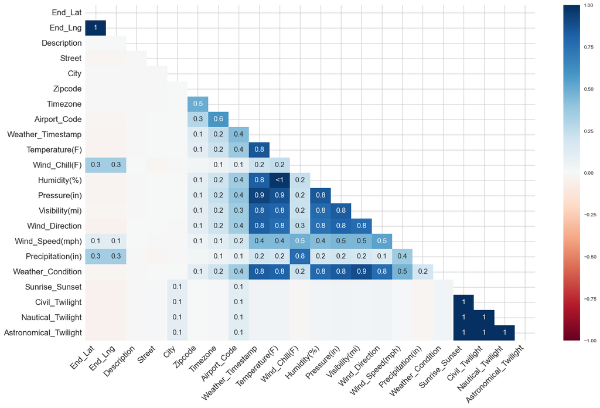

```python
msgno.heatmap(data);
```

Good to know:

- Confirmed that Latitude/Longitude Data are strictly missing together.
- Weather data seems to be missing together in general but not perfectly missing and not a uniform relationship (Precipitation and Wind Direction for example).
- The day/night variables are strictly missing together.

## Duplicates

There are no duplicates to deal with:

```python
if _SPARK_:
    duplicates = int(data.count() - data.dropDuplicates().count())
    duplicates.show()
else:
    print(data.duplicated().sum())
```

```
0
```

## Outliers

```python
if _SPARK_:
    pass
else:
    print(pd.DataFrame({c:{z:count_outliers(data[c],z) for z in [3,5,10,15,20]} for c in _NUMERICS_}).T)
```

```
                       3      5     10    15    20
Distance(mi)       109071  39983  9533  3722  1736
Temperature(F)          0      0     0     0     0
Wind_Chill(F)           0      0     0     0     0
Humidity(%)             0      0     0     0     0
Pressure(in)            0      0     0     0     0
Visibility(mi)          0      0     0     0     0
Wind_Speed(mph)         0      0     0     0     0
Precipitation(in)       0      0     0     0     0
```

The distance feature may have some outlier issues. However, this may be a function of the feature's nature as almost all incidents will not impact a large swath of the road.

## High-Level Features

### Nature of Accident

```python
data['Severity'].value_counts()
```

```
Severity
2    6156981
3    1299337
4     204710
1      67366
Name: count, dtype: int64
```

```python
data['Distance(mi)'].value_counts(bins=25).sort_index(ascending=True)
```

```
(-0.443, 17.67]     7717933
(17.67, 35.34]         8616
(35.34, 53.01]         1208
(53.01, 70.68]          380
(70.68, 88.35]          137
(88.35, 106.02]          50
(106.02, 123.69]         28
(123.69, 141.36]         11
(141.36, 159.03]         13
(159.03, 176.7]           6
(176.7, 194.37]           2
(194.37, 212.04]          2
(212.04, 229.71]          2
(229.71, 247.38]          1
(247.38, 265.05]          2
(265.05, 282.72]          0
(282.72, 300.39]          0
(300.39, 318.06]          0
(318.06, 335.73]          1
(335.73, 353.4]           1
(353.4, 371.07]           0
(371.07, 388.74]          0
(388.74, 406.41]          0
(406.41, 424.08]          0
(424.08, 441.75]          1
Name: count, dtype: int64
```

```python
(data['Distance(mi)']==0).sum()/data.shape[0]
```

```
0.4272764820220087
```

```python
data[data['Distance(mi)']==0].groupby('Severity').count()
```

| Severity | ID | Source | Start_Time | End_Time | Start_Lat | Start_Lng | End_Lat | End_Lng | Distance(mi) | Description | Street | City | County | State | Zipcode | Country | Timezone | Airport_Code | Weather_Timestamp | Temperature(F) | Wind_Chill(F) | Humidity(%) | Pressure(in) | Visibility(mi) | Wind_Direction | Wind_Speed(mph) | Precipitation(in) | Weather_Condition | Amenity | … |
| --- | --- | --- | --- | --- | --- | --- | --- | --- | --- | --- | --- | --- | --- | --- | --- | --- | --- | --- | --- | --- | --- | --- | --- | --- | --- | --- | --- | --- | --- | --- |
| 1 | 62876 | 62876 | 62876 | 62876 | 62876 | 62876 | 25131 | 25131 | 62876 | 62876 | 62797 | 62873 | 62876 | 62876 | 62866 | 62876 | 62800 | 62725 | 62284 | 61848 | 60895 | 61717 | 62154 | 62022 | 61757 | 61642 | 59281 | 62010 | 62876 | … |
| 2 | 2289816 | 2289816 | 2289816 | 2289816 | 2289816 | 2289816 | 328689 | 328689 | 2289816 | 2289813 | 2289273 | 2289762 | 2289816 | 2289816 | 2289495 | 2289816 | 2287188 | 2285988 | 2261998 | 2250852 | 1464838 | 2248118 | 2256963 | 2248100 | 2248991 | 2079282 | 1383990 | 2248003 | 2289816 | … |
| 3 | 940201 | 940201 | 940201 | 940201 | 940201 | 940201 | 40389 | 40389 | 940201 | 940199 | 939521 | 940194 | 940201 | 940201 | 940005 | 940201 | 939694 | 937772 | 927420 | 921484 | 547624 | 920562 | 923949 | 918730 | 922619 | 840001 | 525814 | 918761 | 940201 | … |
| 4 | 9268 | 9268 | 9268 | 9268 | 9268 | 9268 | 7263 | 7263 | 9268 | 9268 | 9268 | 9267 | 9268 | 9268 | 9260 | 9268 | 9256 | 9243 | 9157 | 9101 | 6830 | 9087 | 9119 | 9070 | 9022 | 8450 | 6643 | 9054 | 9268 | … |

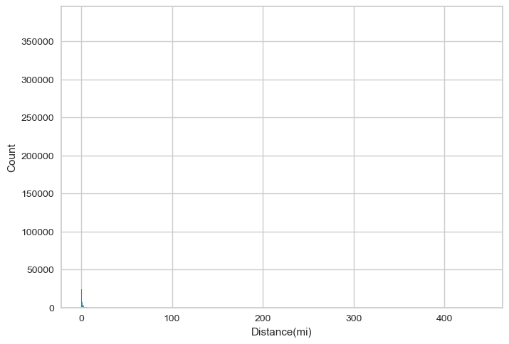

```python
sns.histplot(data[data['Distance(mi)'] > 0]['Distance(mi)']);
```

### Time Features

It is required to set the 'format' parameter to "mixed". (Too many observations to understand why / explore observations setting off the error.)

```python
start = pd.to_datetime(data['Start_Time'],format='mixed')
end = pd.to_datetime(data['End_Time'],format='mixed')
time_change = (end - start).astype('timedelta64[s]').dt.seconds/360
time_change
```

```
0         52.333
1          5.000
2          5.000
3          5.000
4          5.000
           ...
7728389    4.767
7728390    4.481
7728391    4.744
7728392    4.892
7728393    4.903
Length: 7728394, dtype: float64
```

```python
time_change.describe()
```

```
count   7728394.000
mean         18.126
std          20.991
min           0.000
25%           5.247
50%          12.464
75%          20.769
max         239.997
dtype: float64
```

```python
time_change.value_counts(bins=25).sort_index(ascending=True)
```

```
(-0.241, 9.6]         3063780
(9.6, 19.2]           2409415
(19.2, 28.8]          1144834
(28.8, 38.4]           270627
(38.4, 47.999]         171475
(47.999, 57.599]        65523
(57.599, 67.199]       419477
(67.199, 76.799]        31229
(76.799, 86.399]        25462
(86.399, 95.999]        19232
(95.999, 105.599]       16032
(105.599, 115.199]      15308
(115.199, 124.799]      15904
(124.799, 134.398]      18083
(134.398, 143.998]      13597
(143.998, 153.598]       9024
(153.598, 163.198]       5377
(163.198, 172.798]       2987
(172.798, 182.398]       2269
(182.398, 191.998]       1559
(191.998, 201.598]       1347
(201.598, 211.198]       1126
(211.198, 220.797]       1276
(220.797, 230.397]       1436
(230.397, 239.997]       2015
Name: count, dtype: int64
```

There may be some clustering around zero as well but it does not appear to be as much of an issue as with Distance.

```python
(time_change<=0).sum()
```

```
186
```

### Address Features

```python
data['Country'].value_counts()
```

```
Country
US    7728394
Name: count, dtype: int64
```

We can cut this 'Country' feature entirely from the data going forward.

```python
unclean = data['State'].str.startswith(' ').sum() + data['State'].str.endswith(' ').sum()
unclean
```

```
0
```

```python
data['State'].value_counts(dropna=False,normalize=True)
```

```
State
CA   0.225
FL   0.114
TX   0.075
SC   0.050
NY   0.045
NC   0.044
VA   0.039
PA   0.038
MN   0.025
OR   0.023
AZ   0.022
GA   0.022
IL   0.022
TN   0.022
MI   0.021
LA   0.019
NJ   0.018
MD   0.018
OH   0.015
WA   0.014
AL   0.013
UT   0.013
CO   0.012
OK   0.011
MO   0.010
CT   0.009
IN   0.009
MA   0.008
WI   0.004
KY   0.004
NE   0.004
MT   0.004
IA   0.003
AR   0.003
NV   0.003
KS   0.003
DC   0.002
RI   0.002
MS   0.002
DE   0.002
WV   0.002
ID   0.001
NM   0.001
NH   0.001
WY   0.000
ND   0.000
ME   0.000
VT   0.000
SD   0.000
Name: proportion, dtype: float64
```

California seems very high even adjusting for population and area size. It appears we do not have data from the territories like Puerto Rico (PR), US Virgin Islands (VI) but we do have data from District of Columbia (DC).

```python
unclean = data['City'].str.startswith(' ').sum() + data['City'].str.endswith(' ').sum()
unclean
```

```
0
```

```python
data['City'].value_counts(dropna=False,normalize=True).sort_values(ascending=False).head(25)
```

```
City
Miami           0.024
Houston         0.022
Los Angeles     0.020
Charlotte       0.018
Dallas          0.017
Orlando         0.014
Austin          0.013
Raleigh         0.011
Nashville       0.009
Baton Rouge     0.009
Atlanta         0.009
Sacramento      0.009
San Diego       0.007
Phoenix         0.007
Minneapolis     0.007
Richmond        0.006
Oklahoma City   0.006
Jacksonville    0.005
Tucson          0.005
Columbia        0.005
San Antonio     0.005
Greenville      0.005
Saint Paul      0.005
Seattle         0.005
Portland        0.005
Name: proportion, dtype: float64
```

No concerns with balance (or over-representation). Interesting to see some of these cities make it in the top 25.

```python
unclean = data['Zipcode'].str.startswith(' ').sum() + data['Zipcode'].str.endswith(' ').sum()
unclean
```

```
0
```

```python
data['Zipcode'].value_counts(dropna=False,normalize=True).sort_values(ascending=False)
```

```
Zipcode
91761        0.001
91706        0.001
92407        0.001
92507        0.001
33186        0.001
              ...
95829-9419   0.000
23464-8533   0.000
33187-1958   0.000
32606-5861   0.000
94401-2213   0.000
Name: proportion, Length: 825095, dtype: float64
```

```python
unclean = data['Airport_Code'].str.startswith(' ').sum() + data['Airport_Code'].str.endswith(' ').sum()
unclean
```

```
0
```

```python
data['Airport_Code'].value_counts(dropna=False,normalize=True).sort_values(ascending=False)
```

```
Airport_Code
KCQT   0.015
KRDU   0.014
KMCJ   0.013
KBNA   0.013
KCLT   0.013
        ...
KIEN   0.000
K8D3   0.000
KAVK   0.000
KY22   0.000
KICR   0.000
Name: proportion, Length: 2046, dtype: float64
```

Upon further review, this may be indication that this feature is not the traditional airport codes but weather stations! If that is the case, this feature would have limited analytical value (for now).

```python
lax_count = data[data['Airport_Code']=='LAX'].shape[0]
print(f'There are {lax_count} incidents with LAX as its airport code.')
```

```
There are 0 incidents with LAX as its airport code.
```

#### Street Type

```python
unclean = data['Street'].str.startswith(' ').sum() + data['Street'].str.endswith(' ').sum()
unclean
```

```
1696520
```

We need to make sure we clean up the street name.

```python
streets = data['Street'].str.strip()
```

```python
unclean = streets.str.startswith(' ').sum() + streets.str.endswith(' ').sum()
unclean
```

```
0
```

```python
streets.value_counts(dropna=False,normalize=True).sort_values(ascending=False).head(25)
```

```
Street
I-95 N     0.010
I-95 S     0.010
I-5 N      0.009
I-10 E     0.007
I-10 W     0.007
I-5 S      0.007
I-80 W     0.005
I-80 E     0.005
I-405 N    0.004
I-75 N     0.004
I-75 S     0.004
I-90 E     0.003
I-15 N     0.003
I-94 W     0.003
I-90 W     0.003
US-101 N   0.003
I-95       0.003
I-94 E     0.003
I-70 E     0.003
I-15 S     0.002
I-40 W     0.002
I-84 E     0.002
I-35 N     0.002
I-405 S    0.002
I-40 E     0.002
Name: proportion, dtype: float64
```

Not surprising. We may want to use this information in feature engineering below.

Need to figure out if there is a consistent syntax for street address.

```python
highways = streets.str.startswith('US').sum()+ streets.str.startswith('United States').sum()

interstates = streets.str.startswith('I-').sum() + streets.str.startswith('Interstate').sum()

fed_roads = highways + interstates

msg = f'There are roughly {fed_roads} incidents which occured on a federal roads:  '
msg += f'{highways} on a numbered highways and {interstates} interstates.'

print(msg)
```

```
There are roughly 2203298 incidents which occured on a federal roads:  275448 on a numbered highways and 1927850 interstates.
```

Resources on Road Types & Naming Syntax: **Google** on the difference between US numbered highways and US interstate highway system

https://99percentinvisible.org/article/beyond-streets-avenues-simple-visual-guide-different-types-roads/

```python
highways = streets[streets.str.contains('Highway',na=False)]
highways.value_counts(dropna=False,normalize=True).sort_values(ascending=False)
```

```
Street
Pearl Harbor Memorial Highway   0.014
Highway 101                     0.013
US Highway 19 N                 0.012
Highway 20                      0.012
US Highway 1                    0.010
                                 ...
652-838 State Highway 299       0.000
641-408 State Highway 299 E     0.000
State Highway 102               0.000
US Highway 425 N                0.000
GA Highway 133 N                0.000
Name: proportion, Length: 5388, dtype: float64
```

```python
routes = streets[streets.str.startswith('Rt',na=False) | streets.str.startswith('Route',na=False)]
print(routes.shape[0])
routes.value_counts(dropna=False,normalize=True).sort_values(ascending=False)
```

```
16323
```

```
Street
Route 9      0.098
Route 22     0.051
Route 6      0.045
Route 146    0.027
Route 82     0.026
              ...
Route 872    0.000
Route 74 E   0.000
Route 129    0.000
Route 547    0.000
Route 426    0.000
Name: proportion, Length: 405, dtype: float64
```

```python
routes = streets.str.startswith('Route').sum() + streets.str.startswith('Rt').sum()
routes
```

```
16323
```

### Weather

```python
weather_factors = ['Temperature(F)','Wind_Chill(F)',
                   'Humidity(%)','Pressure(in)',
                   'Visibility(mi)','Wind_Speed(mph)',
                   'Precipitation(in)']

data[weather_factors].describe()
```

|  | Temperature(F) | Wind_Chill(F) | Humidity(%) | Pressure(in) | Visibility(mi) | Wind_Speed(mph) | Precipitation(in) |
| --- | --- | --- | --- | --- | --- | --- | --- |
| count | 7564541.000 | 5729375.000 | 7554250.000 | 7587715.000 | 7551296.000 | 7157161.000 | 5524808.000 |
| mean | 61.663 | 58.251 | 64.831 | 29.539 | 9.090 | 7.685 | 0.008 |
| std | 19.014 | 22.390 | 22.821 | 1.006 | 2.688 | 5.425 | 0.110 |
| min | -89.000 | -89.000 | 1.000 | 0.000 | 0.000 | 0.000 | 0.000 |
| 25% | 49.000 | 43.000 | 48.000 | 29.370 | 10.000 | 4.600 | 0.000 |
| 50% | 64.000 | 62.000 | 67.000 | 29.860 | 10.000 | 7.000 | 0.000 |
| 75% | 76.000 | 75.000 | 84.000 | 30.030 | 10.000 | 10.400 | 0.000 |
| max | 207.000 | 207.000 | 100.000 | 58.630 | 140.000 | 1087.000 | 36.470 |

```python
weather_descriptions = data['Weather_Condition'].unique()
print(f'There are {weather_descriptions.shape[0]} ways that the weather is described in this dataset: \n')
print(weather_descriptions)
```

```
There are 145 ways that the weather is described in this dataset:

['Light Rain' 'Overcast' 'Mostly Cloudy' 'Rain' 'Light Snow' 'Haze'
 'Scattered Clouds' 'Partly Cloudy' 'Clear' 'Snow'
 'Light Freezing Drizzle' 'Light Drizzle' 'Fog' 'Shallow Fog' 'Heavy Rain'
 'Light Freezing Rain' 'Cloudy' 'Drizzle' nan 'Light Rain Showers' 'Mist'
 'Smoke' 'Patches of Fog' 'Light Freezing Fog' 'Light Haze'
 'Light Thunderstorms and Rain' 'Thunderstorms and Rain' 'Fair'
 'Volcanic Ash' 'Blowing Sand' 'Blowing Dust / Windy' 'Widespread Dust'
 'Fair / Windy' 'Rain Showers' 'Mostly Cloudy / Windy'
 'Light Rain / Windy' 'Hail' 'Heavy Drizzle' 'Showers in the Vicinity'
 'Thunderstorm' 'Light Rain Shower' 'Light Rain with Thunder'
 'Partly Cloudy / Windy' 'Thunder in the Vicinity' 'T-Storm'
 'Heavy Thunderstorms and Rain' 'Thunder' 'Heavy T-Storm' 'Funnel Cloud'
 'Heavy T-Storm / Windy' 'Blowing Snow' 'Light Thunderstorms and Snow'
 'Heavy Snow' 'Low Drifting Snow' 'Light Ice Pellets' 'Ice Pellets'
 'Squalls' 'N/A Precipitation' 'Cloudy / Windy' 'Light Fog' 'Sand'
 'Snow Grains' 'Snow Showers' 'Heavy Thunderstorms and Snow'
 'Rain / Windy' 'Heavy Rain / Windy' 'Heavy Ice Pellets'
 'Light Snow / Windy' 'Heavy Freezing Rain' 'Small Hail'
 'Heavy Rain Showers' 'Thunder / Windy' 'Drizzle and Fog'
 'T-Storm / Windy' 'Blowing Dust' 'Smoke / Windy' 'Haze / Windy' 'Tornado'
 'Light Drizzle / Windy' 'Widespread Dust / Windy' 'Wintry Mix'
 'Wintry Mix / Windy' 'Light Snow with Thunder' 'Fog / Windy'
 'Snow and Thunder' 'Light Snow Shower' 'Sleet' 'Light Snow and Sleet'
 'Snow / Windy' 'Rain Shower' 'Snow and Sleet' 'Light Sleet'
 'Heavy Snow / Windy' 'Freezing Drizzle' 'Light Freezing Rain / Windy'
 'Thunder / Wintry Mix' 'Blowing Snow / Windy' 'Freezing Rain'
 'Light Snow and Sleet / Windy' 'Snow and Sleet / Windy' 'Sleet / Windy'
 'Heavy Freezing Rain / Windy' 'Squalls / Windy'
 'Light Rain Shower / Windy' 'Snow and Thunder / Windy'
 'Light Sleet / Windy' 'Sand / Dust Whirlwinds' 'Mist / Windy'
 'Drizzle / Windy' 'Duststorm' 'Sand / Dust Whirls Nearby'
 'Thunder and Hail' 'Heavy Sleet' 'Freezing Rain / Windy'
 'Light Snow Shower / Windy' 'Partial Fog' 'Thunder / Wintry Mix / Windy'
 'Patches of Fog / Windy' 'Rain and Sleet' 'Light Snow Grains'
 'Partial Fog / Windy' 'Sand / Dust Whirlwinds / Windy'
 'Heavy Snow with Thunder' 'Light Snow Showers' 'Heavy Blowing Snow'
 'Light Hail' 'Heavy Smoke' 'Heavy Thunderstorms with Small Hail'
 'Light Thunderstorm' 'Heavy Freezing Drizzle' 'Light Blowing Snow'
 'Thunderstorms and Snow' 'Dust Whirls' 'Rain Shower / Windy'
 'Sleet and Thunder' 'Heavy Sleet and Thunder' 'Drifting Snow / Windy'
 'Shallow Fog / Windy' 'Thunder and Hail / Windy' 'Heavy Sleet / Windy'
 'Sand / Windy' 'Heavy Rain Shower / Windy' 'Blowing Snow Nearby'
 'Heavy Rain Shower' 'Drifting Snow']
```

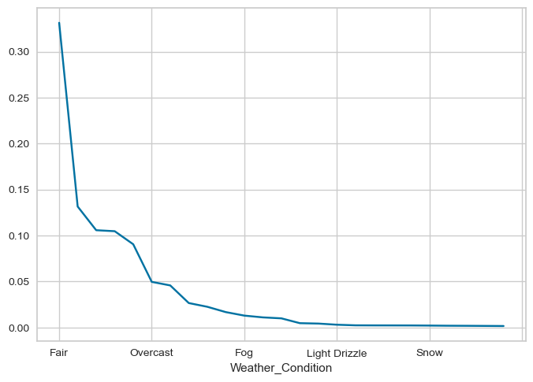

```python
weather_desc_counts = data['Weather_Condition'].value_counts(dropna=False,normalize=True)
weather_desc_counts.sort_values(ascending=False).head(25).plot()
```

This weather condition feature is too granular to be of any analytical value. We need to consider consolidating this feature or ignore it all together. May be of interest to consider how these categories relate to the numeric weather features.

### Night/Day Features

Ultimately, I think dropping all of them except for Sunrise_Sunset is for the best.

```python
print(pd.crosstab(data['Nautical_Twilight'],data['Astronomical_Twilight']))
print('-'*50)
print(pd.crosstab(data['Nautical_Twilight'],data['Civil_Twilight']))
print('-'*50)
print(pd.crosstab(data['Nautical_Twilight'],data['Sunrise_Sunset']))
```

```
Astronomical_Twilight      Day    Night
Nautical_Twilight
Day                    6070128     6028
Night                   307420  1321572
--------------------------------------------------
Civil_Twilight         Day    Night
Nautical_Twilight
Day                5695619   380537
Night                    0  1628992
--------------------------------------------------
Sunrise_Sunset         Day    Night
Nautical_Twilight
Day                5334553   741603
Night                    0  1628992
```

```python
print(pd.crosstab(data['Astronomical_Twilight'],data['Civil_Twilight']))
print('-'*50)
print(pd.crosstab(data['Astronomical_Twilight'],data['Sunrise_Sunset']))
```

```
Civil_Twilight             Day    Night
Astronomical_Twilight
Day                    5689968   687580
Night                     5651  1321949
--------------------------------------------------
Sunrise_Sunset             Day    Night
Astronomical_Twilight
Day                    5329105  1048443
Night                     5448  1322152
```

```python
print(pd.crosstab(data['Civil_Twilight'],data['Sunrise_Sunset']))
```

```
Sunrise_Sunset      Day    Night
Civil_Twilight
Day             5334473   361146
Night                80  2009449
```

### Infrastructure

```python
infrastructures = ['Amenity','Bump','Crossing','Give_Way',
                   'Junction','No_Exit','Railway','Roundabout',
                   'Station','Stop','Traffic_Calming','Traffic_Signal',
                   'Turning_Loop'
                   ]
```

```python
data[infrastructures].sum().sort_values(ascending=False)
```

```
Traffic_Signal     1143772
Crossing            873763
Junction            571342
Stop                214371
Station             201901
Amenity              96334
Railway              66979
Give_Way             36582
No_Exit              19545
Traffic_Calming       7598
Bump                  3514
Roundabout             249
Turning_Loop             0
dtype: int64
```

```python
data[infrastructures].sum(axis=1).value_counts()
```

```
0    5427044
1    1543182
2     609259
3     124709
4      21086
5       2907
6        205
7          2
Name: count, dtype: int64
```

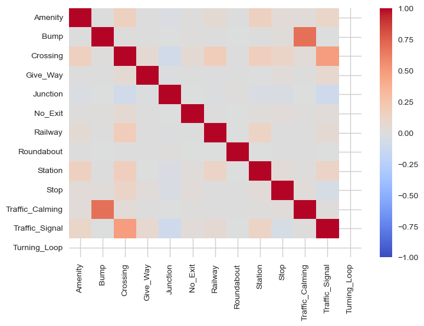

```python
sns.heatmap(data[infrastructures].corr(),vmin=-1,vmax=1,cmap='coolwarm');
```

# 3-Data Processing

Start with a brand new dataset

```python
del data
if _SPARK_:
    spark.stop()
else:
    pass
```

```python
if _SPARK_:
    spark = SparkSession.builder.appName("Accident Data Project").getOrCreate()
    data_clean = spark.read.csv('US_Accidents_March23.csv',header=True,inferSchema=True)
else:
    if _LITE_SWITCH_:
        data_clean = pd.read_csv('US_Accidents_March23_sampled_500k.csv')
    else:
        data_clean = pd.read_csv('US_Accidents_March23.csv')
```

## Drop Unnecessary Columns

```python
bad_features = ['Country','Civil_Twilight','Nautical_Twilight','Astronomical_Twilight','Source']
```

```python
data_clean = data_clean.drop(bad_features,axis=1)
```

## Missing Data

### Ending Longitude/Latitude

### Weather

### Description

### Address

## Outliers

## Engineer Features

### Converting dates

```python
if _SPARK_:
    pass
else:
    data_clean['Start'] = pd.to_datetime(data_clean['Start_Time'],format='mixed')
    data_clean['End'] = pd.to_datetime(data_clean['End_Time'],format='mixed')
```

### Partition the time data

```python
if _SPARK_:
    pass
else:
    data_clean['Month'] = data_clean['Start'].dt.month
    data_clean['Year'] = data_clean['Start'].dt.year
    data_clean['DayofYear'] = data_clean['Start'].dt.dayofyear
    data_clean['DayofMonth'] = data_clean['Start'].dt.day
    data_clean['DayofWeek'] = data_clean['Start'].dt.day_of_week
    data_clean['Quarter'] = data_clean['Start'].dt.quarter
    data_clean['Hour'] = data_clean['Start'].dt.hour
    data_clean['Date'] = data_clean['Start'].dt.date
```

```python
data_clean['Year'].value_counts(normalize=True).sort_index()
```

```
Year
2016   0.053
2017   0.093
2018   0.116
2019   0.123
2020   0.153
2021   0.202
2022   0.228
2023   0.032
Name: proportion, dtype: float64
```

Concern that the two bookend years ('16 & '23) have such low proportion of the data.

```python
data_clean['Month'].value_counts(normalize=True).sort_index()
```

```
Month
1    0.097
2    0.085
3    0.072
4    0.076
5    0.072
6    0.074
7    0.066
8    0.078
9    0.084
10   0.087
11   0.098
12   0.110
Name: proportion, dtype: float64
```

Nothing concerning here.

```python
data_clean['Quarter'].value_counts(normalize=True)
```

```
Quarter
4   0.295
1   0.254
3   0.228
2   0.222
Name: proportion, dtype: float64
```

```python
data_clean['DayofWeek'].value_counts(normalize=True).sort_index()
```

```
DayofWeek
0   0.157
1   0.167
2   0.170
3   0.170
4   0.177
5   0.087
6   0.073
Name: proportion, dtype: float64
```

```python
data_clean['Hour'].value_counts(normalize=True).sort_index()
```

```
Hour
0    0.015
1    0.013
2    0.012
3    0.011
4    0.021
5    0.030
6    0.053
7    0.076
8    0.075
9    0.047
10   0.044
11   0.046
12   0.046
13   0.051
14   0.058
15   0.068
16   0.075
17   0.075
18   0.056
19   0.038
20   0.029
21   0.025
22   0.022
23   0.016
Name: proportion, dtype: float64
```

### Weekend Indicator

```python
data_clean['Weekend'] = ((data_clean['DayofWeek'] == 0) | (data_clean['DayofWeek'] == 6))
```

```python
print(f'There are {data_clean['Weekend'].sum()} observations which occured over the weekend.')
data_clean.groupby('Weekend')['Severity'].mean()
```

```
There are 1773665 observations which occured over the weekend.
```

```
Weekend
False   2.209
True    2.225
Name: Severity, dtype: float64
```

### Holidays Indicator

Per **[Google](https://www.google.com/search?client=safari&rls=en&q=holidays+with+most+traffic&ie=UTF-8&oe=UTF-8)**, there are a number of holidays in the US with the highest amount of traffic. (I subbed NYE in for XMas.)

```python
thanksgivings = [get_thanksgiving_date(y) for y in range(2016,2024)]
memorials = [calculate_memorial_day(y) for y in range(2016,2024)]
labors = [get_labor_day(y) for y in range(2016,2024)]
```

```python
july_4 = ((data_clean['Month'] == 7) & (data_clean['DayofMonth'] == 4))
thanksgiving = data_clean['Date'].apply(lambda d:d in thanksgivings)
memorial = data_clean['Date'].apply(lambda d:d in memorials)
labor = data_clean['Date'].apply(lambda d:d in labors)
nye = ((data_clean['Month'] == 12) & (data_clean['DayofMonth'] == 31))
```

```python
holidays = (july_4 | thanksgiving | memorial | labor | nye)
data_clean['Holiday'] = holidays
```

```python
info = f'''{holidays.sum()} incidents occured on a prime holiday.'''

print(info)
```

```
78572 incidents occured on a prime holiday.
```

### Rush Hour Indicator

**[Per Google:](https://www.google.com/search?client=safari&rls=en&q=rush+hour+typically&ie=UTF-8&oe=UTF-8)** The morning rush hour begins around 6a, peaking between 7a & 9a, and eases off by 10a. While afternoon/evening rush hour begins around 3p, peaking between 4p and 6p, and eases off by 7p.

```python
data_clean['Morning_Rush'] = ((6 > data_clean['DayofWeek']) & (data_clean['DayofWeek'] > 0) & (data_clean['Start'].dt.hour >= 6) & (10 >= data_clean['Start'].dt.hour))
```

```python
print(f'Total of {data_clean['Morning_Rush'].sum()} incidents during the morning rush hour')
```

```
Total of 1788148 incidents during the morning rush hour
```

```python
data_clean['Evening_Rush'] = ((6 > data_clean['DayofWeek']) & (data_clean['DayofWeek'] > 0) & (data_clean['Start'].dt.hour >= 15) & (19 >= data_clean['Start'].dt.hour))
```

```python
print(f'Total of {data_clean['Evening_Rush'].sum()} incidents during the evening rush hour')
```

```
Total of 1879114 incidents during the evening rush hour
```

```python
data_clean['Rush_Hour'] = data_clean['Evening_Rush'] | data_clean['Morning_Rush']
```

States

https://www.faa.gov/air_traffic/publications/atpubs/cnt_html/appendix_a.html

https://apps.bea.gov/regional/geography.htm

https://en.wikipedia.org/wiki/List_of_regions_of_the_United_States

https://www2.census.gov/geo/pdfs/reference/GARM/Ch6GARM.pdf

https://en.wikipedia.org/wiki/Megaregions_of_the_United_States

## Crosstables

```python
#accdidents_year
```

```python
#accidents_calendar
```

Spatial-Based Data

```python
data_clean.State.value_counts(normalize=True).sort_values(ascending=False)
```

```
State
CA   0.225
FL   0.114
TX   0.075
SC   0.050
NY   0.045
NC   0.044
VA   0.039
PA   0.038
MN   0.025
OR   0.023
AZ   0.022
GA   0.022
IL   0.022
TN   0.022
MI   0.021
LA   0.019
NJ   0.018
MD   0.018
OH   0.015
WA   0.014
AL   0.013
UT   0.013
CO   0.012
OK   0.011
MO   0.010
CT   0.009
IN   0.009
MA   0.008
WI   0.004
KY   0.004
NE   0.004
MT   0.004
IA   0.003
AR   0.003
NV   0.003
KS   0.003
DC   0.002
RI   0.002
MS   0.002
DE   0.002
WV   0.002
ID   0.001
NM   0.001
NH   0.001
WY   0.000
ND   0.000
ME   0.000
VT   0.000
SD   0.000
Name: proportion, dtype: float64
```

```python
data_clean['Street'].value_counts(dropna=False).sort_values(ascending=False).head(50)
```

```
Street
I-95 N                78430
I-95 S                74528
I-5 N                 71968
I-10 E                55572
I-10 W                53725
I-5 S                 51781
I-80 W                39662
I-80 E                36113
I-405 N               32364
I-75 N                28166
I-75 S                27546
I-90 E                26426
I-15 N                24470
I-94 W                24003
I-90 W                23279
US-101 N              20041
I-95                  20028
I-94 E                19940
I-70 E                19697
I-15 S                19230
I-40 W                19034
I-84 E                18955
I-35 N                18761
I-405 S               18318
I-40 E                17800
CA-99 N               17651
I-70 W                17402
I-84 W                17311
I-64 E                16611
I-64 W                16072
CA-60 W               15305
I-35 S                15268
CA-99 S               15261
Golden State Fwy S    14869
I-20 W                14453
I-10                  14239
I-880 N               13770
I-85 S                13735
I-20 E                13514
I-65 N                13317
I-26 W                13263
I-75                  13174
I-580 W               13151
CA-60 E               12960
CA-91 W               12932
I-85 N                12869
I-65 S                12663
San Diego Fwy S       12632
I-580 E               12558
I-4 E                 12099
Name: count, dtype: int64
```

### Weather Consolidation

### Nature of Incident

```python
data_clean['Time_of_Impact(hr)'] = (data_clean['End'] - data_clean['Start']).dt.seconds/360
```

```python
data_clean['Time_of_Impact(hr)'].describe()
```

```
count   7728394.000
mean         18.126
std          20.991
min           0.000
25%           5.247
50%          12.464
75%          20.769
max         239.997
Name: Time_of_Impact(hr), dtype: float64
```

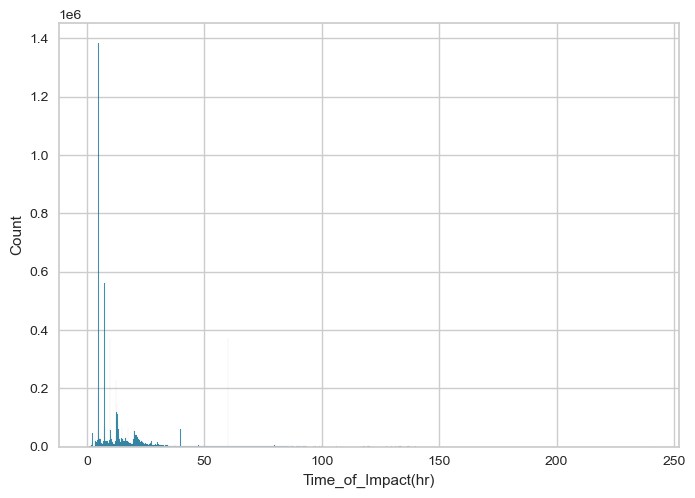

```python
sns.histplot(data_clean['Time_of_Impact(hr)'])
```

## Saveout Data

```python
if _LITE_SWITCH_:
    data_clean.to_csv('AccidentData_Sampled_Clean.csv')
else:
    data_clean.to_csv('AccidentData_Clean.csv')
```

```python
del data_clean
if _SPARK_:
    spark.stop()
else:
    pass
```

# 4-Full EDA

```python
if _SPARK_:
    spark = SparkSession.builder.appName("Accident Data Project").getOrCreate()
    data = spark.read.csv('AccidentData_Clean.csv',header=True,inferSchema=True)
else:
    if _LITE_SWITCH_:
        data = pd.read_csv('AccidentData_Sampled_Clean.csv')
    else:
        data = pd.read_csv('AccidentData_Clean.csv')
```

```python
if _SPARK_:
    data.printSchema()
    print("Features: ",len(data.columns))
    print("Entries:  ",data.count())
else:
    data.info()
```

```
<class 'pandas.core.frame.DataFrame'>
RangeIndex: 7728394 entries, 0 to 7728393
Data columns (total 58 columns):
 #   Column              Dtype
---  ------              -----
 0   Unnamed: 0          int64
 1   ID                  object
 2   Severity            int64
 3   Start_Time          object
 4   End_Time            object
 5   Start_Lat           float64
 6   Start_Lng           float64
 7   End_Lat             float64
 8   End_Lng             float64
 9   Distance(mi)        float64
```

[output cut: 50 more lines]

```python
_TARGET_ = ['Severity']
_NUMERICS_ = ['Distance(mi)','Time_of_Impact(hr)','Temperature(F)',
              'Wind_Chill(F)','Humidity(%)','Pressure(in)',
              'Visibility(mi)','Wind_Speed(mph)','Precipitation(in)']
```

## Nature of Incident Variables

```python
data.groupby('Severity')[['Distance(mi)','Time_of_Impact(hr)']].describe().T
```

|  | Severity | 1 | 2 | 3 | 4 |
| --- | --- | --- | --- | --- | --- |
| Distance(mi) | count | 67366.000 | 6156981.000 | 1299337.000 | 204710.000 |
|  | mean | 0.115 | 0.565 | 0.424 | 1.496 |
|  | std | 0.759 | 1.567 | 2.241 | 3.489 |
|  | min | 0.000 | 0.000 | 0.000 | 0.000 |
|  | 25% | 0.000 | 0.000 | 0.000 | 0.151 |
|  | 50% | 0.000 | 0.068 | 0.000 | 0.473 |
|  | 75% | 0.000 | 0.524 | 0.010 | 1.419 |
|  | max | 25.890 | 227.210 | 441.750 | 152.543 |
| Time_of_Impact(hr) | count | 67366.000 | 6156981.000 | 1299337.000 | 204710.000 |
|  | mean | 7.624 | 19.231 | 11.316 | 31.567 |
|  | std | 4.870 | 21.660 | 13.542 | 28.369 |
|  | min | 2.500 | 0.000 | 0.069 | 0.000 |
|  | 25% | 4.944 | 7.403 | 4.936 | 9.953 |
|  | 50% | 7.458 | 12.914 | 7.400 | 21.136 |
|  | 75% | 9.953 | 21.478 | 10.000 | 60.000 |
|  | max | 147.333 | 239.997 | 239.997 | 239.997 |

```python
if _LITE_SWITCH_:
    sns.histplot(data['Severity'])
else:
    pass
```

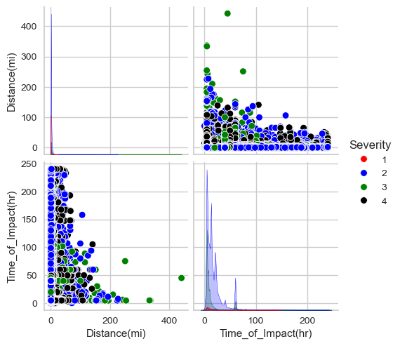

```python
palette = {1:'red',2:'blue',3:'green',4:'black'}
sns.pairplot(data[['Severity','Distance(mi)','Time_of_Impact(hr)']],hue='Severity',palette=palette);
```

## Continuous Variables

### Relationships

```python
if _SPARK_:
    corr_data = data.select(_NUMERICS_+['Severity'])
    col_names = corr_data.columns
    features = corr_data.rdd.map(lambda row: row[0:])
    corrs = Statistics.corr(features, method="pearson")
else:
    corrs = data[_NUMERICS_].corr()
    print(corrs)
```

```
                    Distance(mi)  Time_of_Impact(hr)  Temperature(F)  Wind_Chill(F)  Humidity(%)  Pressure(in)  Visibility(mi)  Wind_Speed(mph)  Precipitation(in)
Distance(mi)               1.000               0.143          -0.054         -0.044        0.009        -0.093          -0.037            0.009             -0.001
Time_of_Impact(hr)         0.143               1.000          -0.014         -0.007       -0.010        -0.008           0.006           -0.002             -0.007
Temperature(F)            -0.054              -0.014           1.000          0.994       -0.331         0.109           0.217            0.034             -0.005
Wind_Chill(F)             -0.044              -0.007           0.994          1.000       -0.315         0.087           0.234           -0.043             -0.012
Humidity(%)                0.009              -0.010          -0.331         -0.315        1.000         0.116          -0.384           -0.172              0.077
Pressure(in)              -0.093              -0.008           0.109          0.087        0.116         1.000           0.038           -0.023              0.017
Visibility(mi)            -0.037               0.006           0.217          0.234       -0.384         0.038           1.000            0.015             -0.120
Wind_Speed(mph)            0.009              -0.002           0.034         -0.043       -0.172        -0.023           0.015            1.000              0.024
Precipitation(in)         -0.001              -0.007          -0.005         -0.012        0.077         0.017          -0.120            0.024              1.000
```

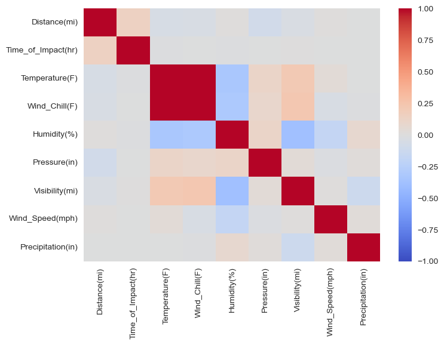

```python
sns.heatmap(corrs,vmin=-1,vmax=1,cmap='coolwarm');
```

## Date

```python
if _SPARK_:
    accdidents_year = data.stat.crosstab('Year','Severity')
else:
    accdidents_year = pd.crosstab(data['Year'],data['Severity'])

    accdidents_year['Total']=accdidents_year.sum(axis=1)
    accdidents_year['Average']=accdidents_year.apply(lambda r:sum(i*r[i] for i in range(1,5))/r['Total'],axis=1)
    accidents_calendar = pd.pivot_table(data,columns='Year',index='Month',values='Severity')
```

```python
display(accdidents_year)
print('*'*75)
display(accidents_calendar)
```

| Severity Year | 1 | 2 | 3 | 4 | Total | Average |
| --- | --- | --- | --- | --- | --- | --- |
| 2016 | 225 | 270026 | 126215 | 14355 | 410821 | 2.377 |
| 2017 | 282 | 462474 | 231169 | 24168 | 718093 | 2.389 |
| 2018 | 259 | 574668 | 292706 | 25793 | 893426 | 2.385 |
| 2019 | 203 | 688144 | 237853 | 28103 | 954303 | 2.308 |
| 2020 | 28371 | 934123 | 185352 | 31067 | 1178913 | 2.186 |
| 2021 | 151 | 1384628 | 148085 | 30889 | 1563753 | 2.134 |
| 2022 | 37875 | 1603346 | 77957 | 43274 | 1762452 | 2.072 |
| 2023 | 0 | 239572 | 0 | 7061 | 246633 | 2.057 |

| Year Month | 2016 | 2017 | 2018 | 2019 | 2020 | 2021 | 2022 | 2023 |
| --- | --- | --- | --- | --- | --- | --- | --- | --- |
| 1 | 4.000 | 2.378 | 2.403 | 2.375 | 2.232 | 2.111 | 2.119 | 2.052 |
| 2 | 2.543 | 2.378 | 2.396 | 2.358 | 2.228 | 2.119 | 2.107 | 2.069 |
| 3 | 2.435 | 2.381 | 2.392 | 2.357 | 2.216 | 2.173 | 2.102 | 2.062 |
| 4 | 2.391 | 2.394 | 2.388 | 2.340 | 2.189 | 2.170 | 2.079 | NaN |
| 5 | 2.374 | 2.403 | 2.388 | 2.350 | 2.236 | 2.173 | 2.039 | NaN |
| 6 | 2.399 | 2.432 | 2.423 | 2.363 | 2.263 | 2.141 | 2.058 | NaN |
| 7 | 2.383 | 2.438 | 2.407 | 2.344 | 2.335 | 2.136 | 2.075 | NaN |
| 8 | 2.372 | 2.369 | 2.377 | 2.314 | 2.352 | 2.134 | 2.062 | NaN |
| 9 | 2.368 | 2.373 | 2.376 | 2.248 | 2.193 | 2.134 | 2.053 | NaN |
| 10 | 2.360 | 2.370 | 2.351 | 2.237 | 2.144 | 2.130 | 2.053 | NaN |
| 11 | 2.370 | 2.384 | 2.359 | 2.258 | 2.105 | 2.124 | 2.056 | NaN |
| 12 | 2.382 | 2.407 | 2.375 | 2.232 | 2.099 | 2.113 | 2.054 | NaN |

### Infrastructure

```python
infrastructures = ['Amenity','Bump','Crossing','Give_Way',
                   'Junction','No_Exit','Railway','Roundabout',
                   'Station','Stop','Traffic_Calming','Traffic_Signal',
                   'Turning_Loop'
                   ]
```

```python
infrastructure_count = pd.DataFrame(columns=infrastructures)
```

### Weather Conditions

```python
weather_descriptions = data.Weather_Condition.unique()
print(f'There are {weather_descriptions.shape[0]} ways that the weather is described in this dataset: \n')
print(weather_descriptions)
```

```
There are 145 ways that the weather is described in this dataset:

['Light Rain' 'Overcast' 'Mostly Cloudy' 'Rain' 'Light Snow' 'Haze'
 'Scattered Clouds' 'Partly Cloudy' 'Clear' 'Snow'
 'Light Freezing Drizzle' 'Light Drizzle' 'Fog' 'Shallow Fog' 'Heavy Rain'
 'Light Freezing Rain' 'Cloudy' 'Drizzle' nan 'Light Rain Showers' 'Mist'
 'Smoke' 'Patches of Fog' 'Light Freezing Fog' 'Light Haze'
 'Light Thunderstorms and Rain' 'Thunderstorms and Rain' 'Fair'
 'Volcanic Ash' 'Blowing Sand' 'Blowing Dust / Windy' 'Widespread Dust'
 'Fair / Windy' 'Rain Showers' 'Mostly Cloudy / Windy'
 'Light Rain / Windy' 'Hail' 'Heavy Drizzle' 'Showers in the Vicinity'
 'Thunderstorm' 'Light Rain Shower' 'Light Rain with Thunder'
 'Partly Cloudy / Windy' 'Thunder in the Vicinity' 'T-Storm'
 'Heavy Thunderstorms and Rain' 'Thunder' 'Heavy T-Storm' 'Funnel Cloud'
 'Heavy T-Storm / Windy' 'Blowing Snow' 'Light Thunderstorms and Snow'
 'Heavy Snow' 'Low Drifting Snow' 'Light Ice Pellets' 'Ice Pellets'
 'Squalls' 'N/A Precipitation' 'Cloudy / Windy' 'Light Fog' 'Sand'
 'Snow Grains' 'Snow Showers' 'Heavy Thunderstorms and Snow'
 'Rain / Windy' 'Heavy Rain / Windy' 'Heavy Ice Pellets'
 'Light Snow / Windy' 'Heavy Freezing Rain' 'Small Hail'
 'Heavy Rain Showers' 'Thunder / Windy' 'Drizzle and Fog'
 'T-Storm / Windy' 'Blowing Dust' 'Smoke / Windy' 'Haze / Windy' 'Tornado'
 'Light Drizzle / Windy' 'Widespread Dust / Windy' 'Wintry Mix'
 'Wintry Mix / Windy' 'Light Snow with Thunder' 'Fog / Windy'
 'Snow and Thunder' 'Light Snow Shower' 'Sleet' 'Light Snow and Sleet'
 'Snow / Windy' 'Rain Shower' 'Snow and Sleet' 'Light Sleet'
 'Heavy Snow / Windy' 'Freezing Drizzle' 'Light Freezing Rain / Windy'
 'Thunder / Wintry Mix' 'Blowing Snow / Windy' 'Freezing Rain'
 'Light Snow and Sleet / Windy' 'Snow and Sleet / Windy' 'Sleet / Windy'
 'Heavy Freezing Rain / Windy' 'Squalls / Windy'
 'Light Rain Shower / Windy' 'Snow and Thunder / Windy'
 'Light Sleet / Windy' 'Sand / Dust Whirlwinds' 'Mist / Windy'
 'Drizzle / Windy' 'Duststorm' 'Sand / Dust Whirls Nearby'
 'Thunder and Hail' 'Heavy Sleet' 'Freezing Rain / Windy'
 'Light Snow Shower / Windy' 'Partial Fog' 'Thunder / Wintry Mix / Windy'
 'Patches of Fog / Windy' 'Rain and Sleet' 'Light Snow Grains'
 'Partial Fog / Windy' 'Sand / Dust Whirlwinds / Windy'
 'Heavy Snow with Thunder' 'Light Snow Showers' 'Heavy Blowing Snow'
 'Light Hail' 'Heavy Smoke' 'Heavy Thunderstorms with Small Hail'
 'Light Thunderstorm' 'Heavy Freezing Drizzle' 'Light Blowing Snow'
 'Thunderstorms and Snow' 'Dust Whirls' 'Rain Shower / Windy'
 'Sleet and Thunder' 'Heavy Sleet and Thunder' 'Drifting Snow / Windy'
 'Shallow Fog / Windy' 'Thunder and Hail / Windy' 'Heavy Sleet / Windy'
 'Sand / Windy' 'Heavy Rain Shower / Windy' 'Blowing Snow Nearby'
 'Heavy Rain Shower' 'Drifting Snow']
```

```python
description_counts = data.Weather_Condition.value_counts(dropna=False,normalize=True)
description_counts.sort_values(ascending=False)
```

```
Weather_Condition
Fair                  0.331
Mostly Cloudy         0.131
Cloudy                0.106
Clear                 0.105
Partly Cloudy         0.090
                       ...
Dust Whirls           0.000
Heavy Sleet / Windy   0.000
Partial Fog / Windy   0.000
Heavy Smoke           0.000
Drifting Snow         0.000
Name: proportion, Length: 145, dtype: float64
```

#### Exploration of Weather Condition Consolidation

```python
weather_factors = ['Temperature(F)','Wind_Chill(F)','Humidity(%)',
                   'Pressure(in)','Visibility(mi)',
                   'Wind_Speed(mph)','Precipitation(in)']
```

```python
X = data[weather_factors].dropna()
scaler = StandardScaler()
X_std =scaler.fit_transform(X)
```

```python
pca = PCA()
pca.fit(X_std);
```

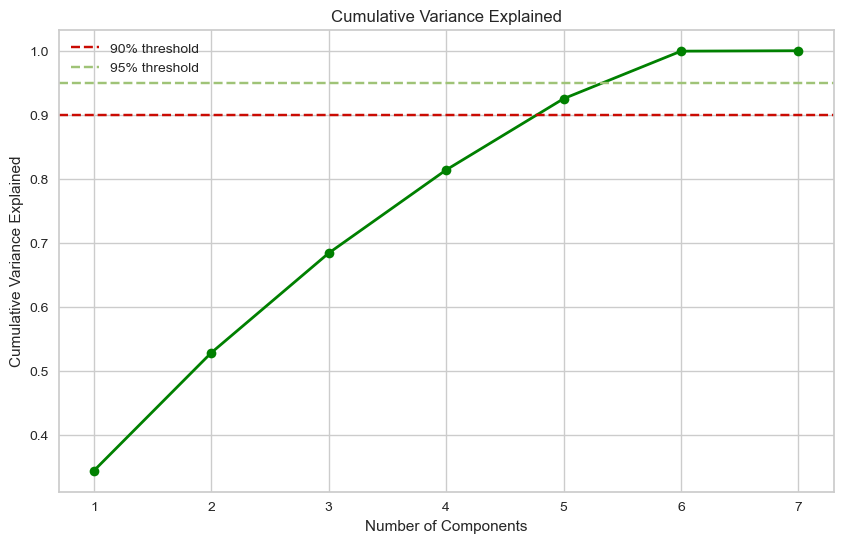

```python
cumulative_var = np.cumsum(pca.explained_variance_ratio_)
# Create a cumulative variance plot
plt.figure(figsize=(10, 6))
cum_var_plot = plt.plot(range(1, len(cumulative_var) + 1), cumulative_var,
         'o-', linewidth=2, color='green')
# Add lines for 90% and 95% thresholds
plt.axhline(y=0.9, color='r', linestyle='--', label='90% threshold')
plt.axhline(y=0.95, color='g', linestyle='--', label='95% threshold')
plt.title('Cumulative Variance Explained')
plt.xlabel('Number of Components')
plt.ylabel('Cumulative Variance Explained')
plt.legend()
plt.grid(True)
plt.show()
```

```python
target_variance = 0.95
n_components_variance = np.argmax(cumulative_var >= target_variance) + 1
print(f'We choose to include the first {n_components_variance} components.')
```

```
We choose to include the first 6 components.
```

```python
pca = PCA(n_components=n_components_variance)
pca.fit(X_std);
# Transform the standardized data to get principal components
X_pca = pca.transform(X_std)

# Create a DataFrame with the principal components
pca_df = pd.DataFrame(
    data=X_pca,
    columns=[f'PC{i+1}' for i in range(X_pca.shape[1])]
)
pca_df
```

|  | PC1 | PC2 | PC3 | PC4 | PC5 | PC6 |
| --- | --- | --- | --- | --- | --- | --- |
| 0 | -2.269 | 0.848 | -0.355 | -0.133 | 0.193 | 0.169 |
| 1 | -2.895 | 1.271 | 0.119 | 0.016 | -0.888 | -0.486 |
| 2 | -2.895 | 1.271 | 0.119 | 0.016 | -0.888 | -0.486 |
| 3 | -2.895 | 1.271 | 0.119 | 0.016 | -0.888 | -0.486 |
| 4 | -3.243 | 1.246 | 0.092 | 0.094 | -1.134 | -0.726 |
| ... | ... | ... | ... | ... | ... | ... |
| 5246806 | 2.064 | -0.617 | 0.887 | 0.140 | -0.452 | -0.005 |
| 5246807 | 0.534 | 0.340 | -0.291 | -0.170 | -0.063 | 0.489 |
| 5246808 | 0.934 | 0.151 | 0.146 | 0.467 | -0.049 | 0.307 |
| 5246809 | 0.496 | 0.522 | -0.143 | 0.217 | -0.138 | 0.791 |
| 5246810 | 1.047 | -0.027 | 0.545 | -0.699 | -1.003 | -0.629 |

5246811 rows × 6 columns

```python
# Create an easy to view DF of the loadings.
loadings = pd.DataFrame(
    pca.components_.T,
    columns=[f'PC{i+1}' for i in range(n_components_variance)],
    index=weather_factors
)
loadings
```

|  | PC1 | PC2 | PC3 | PC4 | PC5 | PC6 |
| --- | --- | --- | --- | --- | --- | --- |
| Temperature(F) | 0.595 | 0.242 | 0.116 | -0.081 | -0.238 | 0.106 |
| Wind_Chill(F) | 0.592 | 0.264 | 0.080 | -0.114 | -0.223 | 0.105 |
| Humidity(%) | -0.390 | 0.478 | -0.098 | 0.055 | -0.200 | 0.753 |
| Pressure(in) | 0.097 | 0.541 | -0.238 | 0.673 | 0.326 | -0.286 |
| Visibility(mi) | 0.351 | -0.340 | -0.316 | 0.030 | 0.624 | 0.521 |
| Wind_Speed(mph) | 0.055 | -0.341 | 0.613 | 0.653 | -0.138 | 0.241 |
| Precipitation(in) | -0.082 | 0.345 | 0.662 | -0.312 | 0.582 | 0.003 |

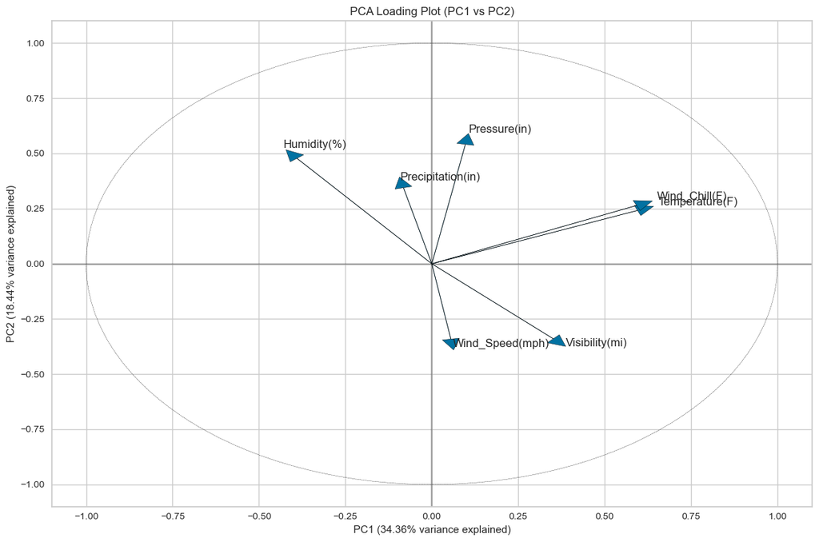

```python
# Visualize the loadings for the first two PCs
plt.figure(figsize=(12, 8))
for i, feature in enumerate(weather_factors):
    plt.arrow(0, 0, loadings.iloc[i, 0], loadings.iloc[i, 1], head_width=0.05, head_length=0.05)
    plt.text(loadings.iloc[i, 0]*1.1, loadings.iloc[i, 1]*1.1, feature, fontsize=12)

# Add a unit circle for reference
circle = plt.Circle((0, 0), 1, fill=False, linestyle='--')
plt.gca().add_patch(circle)

plt.grid(True)
plt.axhline(y=0, color='k', linestyle='-', alpha=0.3)
plt.axvline(x=0, color='k', linestyle='-', alpha=0.3)
plt.xlim(-1.1, 1.1)
plt.ylim(-1.1, 1.1)
plt.title('PCA Loading Plot (PC1 vs PC2)')
plt.xlabel(f'PC1 ({pca.explained_variance_ratio_[0]:.2%} variance explained)')
plt.ylabel(f'PC2 ({pca.explained_variance_ratio_[1]:.2%} variance explained)')
plt.tight_layout()
plt.show()
```

```python
X = data[weather_factors+['Weather_Condition']].dropna()[weather_factors]
scaler = StandardScaler()
X_std =scaler.fit_transform(X)
```

[output not shown]

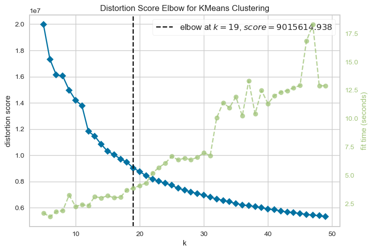

```python
km = KMeans(random_state=42)
visualizer = KElbowVisualizer(km,k=(5,50))
visualizer.fit(X_std)
visualizer.show();
```

Recall, the heavily-skewed distribution of weather descripitions.

```python
km = KMeans(random_state=42,n_clusters=visualizer.elbow_value_)
km.fit(X_std)
```

```
KMeans(n_clusters=19, random_state=42)
```

```python
centroids = pd.DataFrame(scaler.inverse_transform(km.cluster_centers_),columns=weather_factors)
centroids
```

|  | Temperature(F) | Wind_Chill(F) | Humidity(%) | Pressure(in) | Visibility(mi) | Wind_Speed(mph) | Precipitation(in) |
| --- | --- | --- | --- | --- | --- | --- | --- |
| 0 | 67.381 | 67.381 | 81.438 | 29.659 | 9.608 | 0.906 | 0.001 |
| 1 | 43.374 | 37.036 | 67.715 | 29.406 | 9.621 | 16.344 | 0.004 |
| 2 | 67.235 | 67.235 | 36.111 | 29.558 | 9.877 | 4.486 | 0.000 |
| 3 | 56.785 | 56.392 | 91.256 | 29.574 | 3.103 | 4.835 | 0.016 |
| 4 | 48.518 | 47.001 | 51.973 | 29.620 | 9.972 | 5.540 | 0.000 |
| 5 | 62.278 | 61.432 | 91.336 | 29.465 | 3.900 | 9.775 | 0.247 |
| 6 | 28.482 | 19.928 | 88.709 | 29.222 | 2.291 | 10.829 | 0.015 |
| 7 | 69.096 | 68.843 | 30.419 | 25.730 | 10.038 | 8.395 | 0.000 |
| 8 | 42.563 | 41.386 | 83.650 | 29.634 | 9.574 | 2.850 | 0.002 |
| 9 | 80.841 | 80.841 | 60.498 | 29.694 | 9.923 | 6.678 | 0.000 |
| 10 | 88.393 | 88.393 | 29.875 | 29.246 | 9.850 | 8.359 | 0.000 |
| 11 | 40.395 | 34.718 | 73.421 | 30.273 | 7.907 | 10.770 | 11.710 |
| 12 | 79.603 | 79.603 | 61.398 | 29.730 | 9.868 | 14.904 | 0.001 |
| 13 | 32.036 | 26.896 | 73.515 | 25.066 | 8.099 | 7.145 | 0.004 |
| 14 | 64.961 | 64.242 | 35.512 | 26.757 | 53.105 | 8.429 | 0.000 |
| 15 | 23.351 | 14.673 | 69.339 | 29.366 | 9.699 | 8.720 | 0.000 |
| 16 | 66.123 | 66.123 | 81.528 | 29.647 | 9.678 | 7.805 | 0.003 |
| 17 | 63.489 | 63.313 | 38.003 | 29.534 | 9.982 | 14.753 | 0.000 |
| 18 | 69.795 | 69.594 | 91.535 | 29.581 | 3.792 | 9.121 | 0.920 |

```python
pd.Series(km.labels_).value_counts(normalize=True).sort_values(ascending=False)
```

```
16   0.126
9    0.117
8    0.092
0    0.086
4    0.079
2    0.079
12   0.070
10   0.064
3    0.061
17   0.046
1    0.041
15   0.040
6    0.037
7    0.027
13   0.024
5    0.010
18   0.001
14   0.000
11   0.000
Name: proportion, dtype: float64
```

```python
described_obsv = pd.DataFrame(data[weather_factors+['Weather_Condition']].dropna()['Weather_Condition'])
described_obsv['Cluster'] = km.labels_
described_obsv['Severity'] = data['Severity']
described_obsv['Distance(mi)'] = data['Distance(mi)']
described_obsv
```

|  | Weather_Condition | Cluster | Severity | Distance(mi) |
| --- | --- | --- | --- | --- |
| 5 | Light Rain | 8 | 3 | 0.010 |
| 9 | Light Rain | 3 | 3 | 0.010 |
| 11 | Light Rain | 3 | 3 | 0.010 |
| 14 | Light Rain | 3 | 2 | 0.010 |
| 20 | Light Snow | 6 | 2 | 0.000 |
| ... | ... | ... | ... | ... |
| 7728389 | Fair | 10 | 2 | 0.543 |
| 7728390 | Fair | 16 | 2 | 0.338 |
| 7728391 | Partly Cloudy | 9 | 2 | 0.561 |
| 7728392 | Fair | 16 | 2 | 0.772 |
| 7728393 | Fair | 9 | 2 | 0.537 |

5237610 rows × 4 columns

```python
cluster_v_descr = pd.crosstab(described_obsv['Cluster'],described_obsv['Weather_Condition'])
cluster_v_descr
```

| Weather_Condition Cluster | Blowing Dust | Blowing Dust / Windy | Blowing Sand | Blowing Snow | Blowing Snow / Windy | Blowing Snow Nearby | Clear | Cloudy | Cloudy / Windy | Drifting Snow | Drifting Snow / Windy | Drizzle | Drizzle / Windy | Drizzle and Fog | Fair | Fair / Windy | Fog | Fog / Windy | Freezing Drizzle | Freezing Rain | Freezing Rain / Windy | Funnel Cloud | Hail | Haze | Haze / Windy | Heavy Drizzle | Heavy Freezing Drizzle | Heavy Freezing Rain | Heavy Freezing Rain / Windy | … |
| --- | --- | --- | --- | --- | --- | --- | --- | --- | --- | --- | --- | --- | --- | --- | --- | --- | --- | --- | --- | --- | --- | --- | --- | --- | --- | --- | --- | --- | --- | --- |
| 0 | 0 | 0 | 0 | 0 | 0 | 0 | 0 | 83271 | 0 | 0 | 0 | 162 | 0 | 0 | 243050 | 0 | 28 | 0 | 0 | 0 | 0 | 1 | 0 | 4362 | 0 | 8 | 0 | 0 | 0 | … |
| 1 | 0 | 19 | 0 | 24 | 70 | 0 | 99 | 59648 | 9371 | 0 | 6 | 118 | 13 | 0 | 48831 | 8623 | 1 | 9 | 0 | 1 | 0 | 0 | 0 | 349 | 224 | 2 | 0 | 5 | 1 | … |
| 2 | 62 | 0 | 1 | 0 | 0 | 0 | 0 | 16718 | 0 | 0 | 0 | 0 | 0 | 0 | 322101 | 0 | 0 | 0 | 0 | 0 | 0 | 0 | 0 | 3285 | 0 | 0 | 0 | 0 | 0 | … |
| 3 | 1 | 0 | 0 | 0 | 0 | 0 | 2 | 53202 | 29 | 0 | 0 | 1361 | 0 | 306 | 24146 | 1 | 68060 | 29 | 7 | 0 | 0 | 0 | 14 | 19986 | 20 | 215 | 0 | 0 | 0 | … |
| 4 | 4 | 0 | 0 | 0 | 0 | 0 | 80 | 59334 | 0 | 0 | 0 | 47 | 0 | 0 | 269677 | 0 | 0 | 0 | 0 | 0 | 0 | 0 | 5 | 839 | 0 | 0 | 0 | 0 | 0 | … |
| 5 | 0 | 0 | 0 | 0 | 0 | 0 | 0 | 1615 | 43 | 0 | 0 | 13 | 0 | 0 | 204 | 11 | 177 | 19 | 0 | 0 | 0 | 0 | 4 | 44 | 0 | 3 | 0 | 2 | 0 | … |
| 6 | 0 | 1 | 0 | 326 | 793 | 0 | 5 | 15277 | 555 | 0 | 0 | 307 | 5 | 78 | 3256 | 68 | 13471 | 601 | 14 | 150 | 18 | 0 | 0 | 2892 | 916 | 37 | 2 | 2 | 0 | … |
| 7 | 13 | 65 | 0 | 0 | 0 | 0 | 0 | 6332 | 381 | 0 | 0 | 2 | 0 | 0 | 91056 | 2831 | 0 | 0 | 0 | 0 | 0 | 0 | 0 | 838 | 67 | 0 | 0 | 0 | 0 | … |
| 8 | 0 | 0 | 0 | 0 | 0 | 0 | 107 | 113106 | 0 | 0 | 0 | 526 | 0 | 0 | 247073 | 0 | 30 | 0 | 2 | 6 | 0 | 0 | 11 | 2281 | 0 | 5 | 1 | 1 | 0 | … |
| 9 | 1 | 0 | 0 | 0 | 0 | 0 | 0 | 39746 | 0 | 0 | 0 | 7 | 0 | 0 | 310155 | 0 | 0 | 0 | 0 | 0 | 0 | 0 | 0 | 2343 | 0 | 0 | 0 | 0 | 0 | … |
| 10 | 12 | 0 | 0 | 0 | 0 | 0 | 0 | 2992 | 0 | 0 | 0 | 2 | 0 | 0 | 244384 | 515 | 0 | 0 | 0 | 0 | 0 | 0 | 0 | 3664 | 3 | 0 | 0 | 0 | 0 | … |
| 11 | 0 | 0 | 0 | 1 | 0 | 0 | 8 | 3 | 0 | 0 | 0 | 0 | 0 | 0 | 1 | 0 | 0 | 0 | 0 | 0 | 0 | 0 | 0 | 0 | 0 | 0 | 0 | 0 | 0 | … |
| 12 | 12 | 8 | 0 | 0 | 0 | 0 | 0 | 37210 | 3498 | 0 | 0 | 14 | 1 | 0 | 126827 | 6342 | 3 | 1 | 0 | 0 | 0 | 1 | 0 | 746 | 117 | 0 | 0 | 0 | 0 | … |
| 13 | 2 | 3 | 0 | 17 | 26 | 1 | 0 | 25203 | 864 | 0 | 0 | 44 | 2 | 6 | 40434 | 939 | 1955 | 58 | 1 | 11 | 0 | 0 | 0 | 925 | 60 | 1 | 0 | 0 | 0 | … |
| 14 | 0 | 2 | 0 | 0 | 0 | 0 | 0 | 50 | 1 | 0 | 0 | 0 | 0 | 0 | 720 | 49 | 0 | 0 | 0 | 0 | 0 | 0 | 0 | 3 | 0 | 0 | 0 | 0 | 0 | … |
| 15 | 0 | 0 | 0 | 176 | 35 | 0 | 245 | 60146 | 264 | 1 | 0 | 29 | 0 | 0 | 95354 | 567 | 3 | 0 | 6 | 29 | 0 | 0 | 0 | 1010 | 20 | 0 | 0 | 0 | 0 | … |
| 16 | 0 | 0 | 0 | 0 | 0 | 0 | 0 | 196915 | 0 | 0 | 0 | 421 | 0 | 0 | 218221 | 0 | 6 | 0 | 0 | 0 | 0 | 2 | 0 | 2706 | 0 | 6 | 0 | 0 | 0 | … |
| 17 | 74 | 135 | 0 | 0 | 0 | 0 | 2 | 16448 | 1342 | 0 | 0 | 1 | 0 | 0 | 146936 | 14190 | 0 | 0 | 0 | 0 | 0 | 0 | 0 | 376 | 152 | 0 | 0 | 0 | 0 | … |
| 18 | 0 | 0 | 0 | 0 | 0 | 0 | 3 | 144 | 5 | 0 | 0 | 0 | 0 | 0 | 69 | 8 | 7 | 0 | 0 | 0 | 0 | 0 | 0 | 0 | 0 | 0 | 0 | 0 | 0 | … |

```python
cluster_v_sever = pd.crosstab(described_obsv['Cluster'],described_obsv['Severity'])
cluster_v_sever['Average'] = cluster_v_sever.apply(lambda r:sum(r[c]*c for c in range(1,5))/sum(r),axis=1)
cluster_v_sever
```

| Severity Cluster | 1 | 2 | 3 | 4 | Average |
| --- | --- | --- | --- | --- | --- |
| 0 | 9318 | 380090 | 48219 | 12202 | 2.141 |
| 1 | 877 | 177676 | 28591 | 6567 | 2.191 |
| 2 | 3689 | 362233 | 38601 | 7695 | 2.122 |
| 3 | 2871 | 271696 | 37284 | 7487 | 2.155 |
| 4 | 2000 | 363314 | 39043 | 10734 | 2.141 |
| 5 | 505 | 40166 | 9681 | 1077 | 2.220 |
| 6 | 126 | 158944 | 29769 | 6310 | 2.217 |
| 7 | 3693 | 116498 | 17222 | 4645 | 2.161 |
| 8 | 2174 | 423308 | 40808 | 13510 | 2.137 |
| 9 | 9049 | 516164 | 72627 | 13026 | 2.147 |
| 10 | 8109 | 282496 | 38150 | 5936 | 2.125 |
| 11 | 0 | 37 | 19 | 1 | 2.368 |
| 12 | 4712 | 314630 | 42631 | 6011 | 2.136 |
| 13 | 511 | 109788 | 11225 | 4789 | 2.161 |
| 14 | 10 | 1436 | 554 | 47 | 2.312 |
| 15 | 98 | 179044 | 23481 | 6595 | 2.175 |
| 16 | 11926 | 554457 | 77482 | 15153 | 2.145 |
| 17 | 2488 | 207750 | 28134 | 5157 | 2.148 |
| 18 | 71 | 4132 | 985 | 76 | 2.203 |

# 5-Statistical Analysis

Chi-Squared and ANOVA Tests for various features

```python
if _SPARK_:
    spark = SparkSession.builder.appName("Accident Data Project").getOrCreate()
    data = spark.read.csv('AccidentData_Clean.csv',header=True,inferSchema=True)
else:
    if _LITE_SWITCH_:
        data = pd.read_csv('AccidentData_Sampled_Clean.csv')
    else:
        data = pd.read_csv('AccidentData_Clean.csv')
```

## Severity as An Input Feature for Distance and Time of Impact

```python
model_distVseverity = ols("Q('Distance(mi)') ~ C(Severity)", data=data).fit()
anova_table_distVSeverity = sm.stats.anova_lm(model_distVseverity, typ=2)
print("\nANOVA for Distance vs Severity Category:\n", anova_table_distVSeverity)
p_val = anova_table_distVSeverity['PR(>F)'].iloc[0]
print(f"P-value for Distance vs Severity Category: {p_val}")
```

```
ANOVA for Distance vs Severity Category:
                   sum_sq          df         F  PR(>F)
C(Severity)   216911.317       3.000 23107.701   0.000
Residual    24182057.553 7728390.000       NaN     NaN
P-value for Distance vs Severity Category: 0.0
```

```python
model_timeVseverity = ols("Q('Time_of_Impact(hr)') ~ C(Severity)", data=data).fit()
anova_table_timeVseverity = sm.stats.anova_lm(model_timeVseverity, typ=2)
print("\nANOVA for Time of Impact vs Severity Category:\n", anova_table_timeVseverity)
p_val = anova_table_timeVseverity['PR(>F)'].iloc[0]
print(f"P-value for Time of Impact vs Severity Category: {p_val}")
```

```
ANOVA for Time of Impact vs Severity Category:
                     sum_sq          df         F  PR(>F)
C(Severity)  112189050.704       3.000 87763.262   0.000
Residual    3293104361.058 7728390.000       NaN     NaN
P-value for Time of Impact vs Severity Category: 0.0
```

```python
del model_distVseverity, model_timeVseverity
del anova_table_distVSeverity, anova_table_timeVseverity
del p_val
```

## Weather-Related

```python
if _SPARK_:
    spark = SparkSession.builder.appName("Accident Data Project").getOrCreate()
    data = spark.read.csv('AccidentData_Clean.csv',header=True,inferSchema=True)
else:
    if _LITE_SWITCH_:
        data = pd.read_csv('AccidentData_Sampled_Clean.csv')
    else:
        data = pd.read_csv('AccidentData_Clean.csv',usecols = ['Weather_Condition','Distance(mi)','Time_of_Impact(hr)'])
```

### Condition Category

```python
data.value_counts('Weather_Condition').head()
```

```
Weather_Condition
Fair             2560802
Mostly Cloudy    1016195
Cloudy            817082
Clear             808743
Partly Cloudy     698972
Name: count, dtype: int64
```

```python
#reports,stats = test_results('Weather_Condition',data)
```

## Time-Related

```python
if _SPARK_:
    spark = SparkSession.builder.appName("Accident Data Project").getOrCreate()
    data = spark.read.csv('AccidentData_Clean.csv',header=True,inferSchema=True)
else:
    if _LITE_SWITCH_:
        data = pd.read_csv('AccidentData_Sampled_Clean.csv')
    else:
        tgt_cols = ['Month','Quarter','Year','DayofWeek','Weekend','Holiday']
        data = pd.read_csv('AccidentData_Clean.csv',usecols = tgt_cols+['Severity','Distance(mi)','Time_of_Impact(hr)'])
```

### YoY Difference?

```
Based on the ANOVA test's p-value of 0.0, we reject the null hypothesis that there is no significant difference in incident time across different Years.
Based on the ANOVA test's p-value of 0.0, we reject the null hypothesis that there is no significant difference in incident distance across different Years.
Based on the CHI-Squared test's p-value of 0.0, we reject the null hypothesis that there is no significant difference in incident severity across different Years.
```

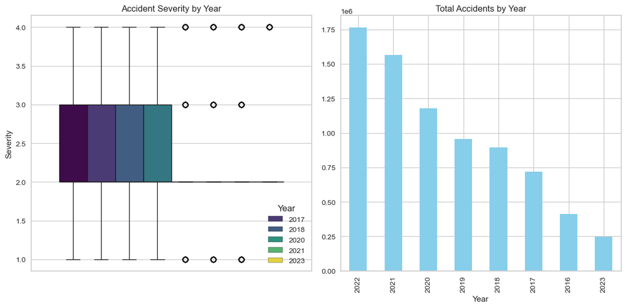

| Year | Severity | Time_of_Impact(hr) | Distance(mi) |
| --- | --- | --- | --- |
| 2016 | 2.377 | 23.775 | 0.253 |
| 2017 | 2.389 | 19.060 | 0.279 |
| 2018 | 2.385 | 11.612 | 0.291 |
| 2019 | 2.308 | 12.363 | 0.300 |
| 2020 | 2.186 | 19.999 | 0.449 |
| 2021 | 2.134 | 21.886 | 0.706 |
| 2022 | 2.072 | 18.045 | 0.926 |
| 2023 | 2.057 | 19.671 | 0.917 |

```python
reports,stats = test_results('Year',data)
data.groupby('Year')[['Severity','Time_of_Impact(hr)','Distance(mi)']].mean()
```

### Quarterly Difference?

```
Based on the ANOVA test's p-value of 0.0, we reject the null hypothesis that there is no significant difference in incident time across different Quarters.
Based on the ANOVA test's p-value of 2.0778151943146088e-239, we reject the null hypothesis that there is no significant difference in incident distance across different Quarters.
Based on the CHI-Squared test's p-value of 0.0, we reject the null hypothesis that there is no significant difference in incident severity across different Quarters.
```

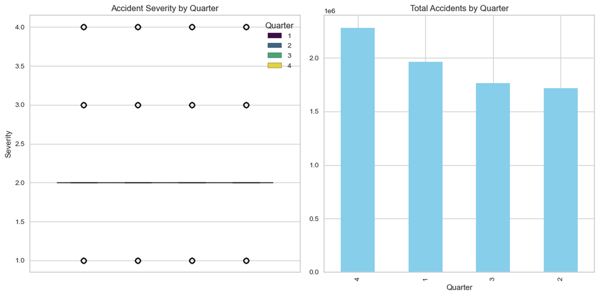

| Quarter | Severity | Time_of_Impact(hr) | Distance(mi) |
| --- | --- | --- | --- |
| 1 | 2.207 | 18.830 | 0.576 |
| 2 | 2.225 | 18.073 | 0.539 |
| 3 | 2.231 | 16.668 | 0.538 |
| 4 | 2.193 | 18.685 | 0.585 |

```python
reports,stats = test_results('Quarter',data)
data.groupby('Quarter')[['Severity','Time_of_Impact(hr)','Distance(mi)']].mean()
```

### Monthly?

```
Based on the ANOVA test's p-value of 0.0, we reject the null hypothesis that there is no significant difference in incident time across different Months.
Based on the ANOVA test's p-value of 0.0, we reject the null hypothesis that there is no significant difference in incident distance across different Months.
Based on the CHI-Squared test's p-value of 0.0, we reject the null hypothesis that there is no significant difference in incident severity across different Months.
```

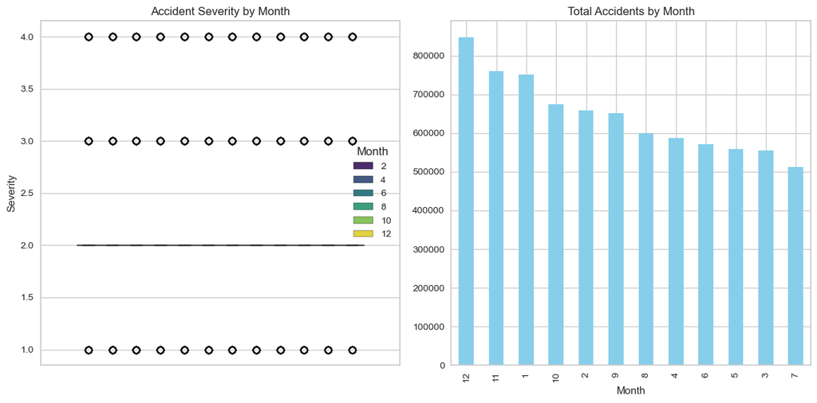

| Month | Severity | Time_of_Impact(hr) | Distance(mi) |
| --- | --- | --- | --- |
| 1 | 2.191 | 18.555 | 0.571 |
| 2 | 2.204 | 19.465 | 0.613 |
| 3 | 2.233 | 18.449 | 0.537 |
| 4 | 2.216 | 18.574 | 0.547 |
| 5 | 2.221 | 18.718 | 0.517 |
| 6 | 2.240 | 16.928 | 0.552 |
| 7 | 2.243 | 17.352 | 0.568 |
| 8 | 2.237 | 16.019 | 0.523 |
| 9 | 2.215 | 16.727 | 0.529 |
| 10 | 2.214 | 17.667 | 0.505 |
| 11 | 2.193 | 18.830 | 0.573 |
| 12 | 2.176 | 19.365 | 0.660 |

```python
reports,stats = test_results('Month',data)
data.groupby('Month')[['Severity','Time_of_Impact(hr)','Distance(mi)']].mean()
```

### Day of Week

```
Based on the ANOVA test's p-value of 0.0, we reject the null hypothesis that there is no significant difference in incident time across different DayofWeeks.
Based on the ANOVA test's p-value of 0.0, we reject the null hypothesis that there is no significant difference in incident distance across different DayofWeeks.
Based on the CHI-Squared test's p-value of 0.0, we reject the null hypothesis that there is no significant difference in incident severity across different DayofWeeks.
```

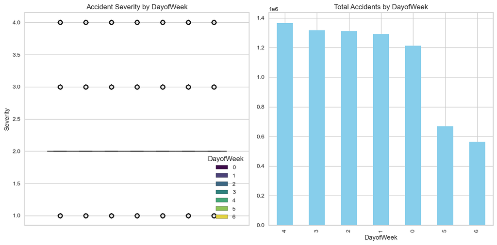

| DayofWeek | Severity | Time_of_Impact(hr) | Distance(mi) |
| --- | --- | --- | --- |
| 0 | 2.209 | 17.574 | 0.516 |
| 1 | 2.205 | 17.755 | 0.532 |
| 2 | 2.203 | 17.806 | 0.540 |
| 3 | 2.204 | 17.934 | 0.557 |
| 4 | 2.207 | 18.492 | 0.574 |
| 5 | 2.241 | 19.453 | 0.633 |
| 6 | 2.259 | 18.889 | 0.677 |

```python
reports,stats = test_results('DayofWeek',data)
data.groupby('DayofWeek')[['Severity','Time_of_Impact(hr)','Distance(mi)']].mean()
```

#### Weekend?

```
Based on the ANOVA test's p-value of 2.8935018205009166e-22, we reject the null hypothesis that there is no significant difference in incident time across different Weekends.
Based on the ANOVA test's p-value of 5.661329587181765e-06, we reject the null hypothesis that there is no significant difference in incident distance across different Weekends.
Based on the CHI-Squared test's p-value of 0.0, we reject the null hypothesis that there is no significant difference in incident severity across different Weekends.
```

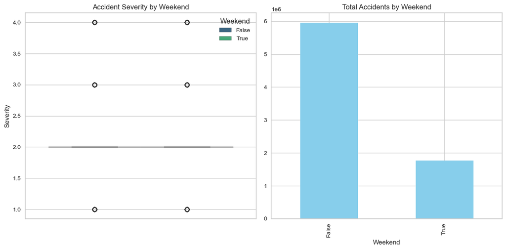

| Weekend | Severity | Time_of_Impact(hr) | Distance(mi) |
| --- | --- | --- | --- |
| False | 2.209 | 18.166 | 0.560 |
| True | 2.225 | 17.991 | 0.567 |

```python
reports,stats = test_results('Weekend',data)
data.groupby('Weekend')[['Severity','Time_of_Impact(hr)','Distance(mi)']].mean()
```

#### Holiday?

```
Based on the ANOVA test's p-value of 2.4219854211971033e-42, we reject the null hypothesis that there is no significant difference in incident time across different Holidays.
Based on the ANOVA test's p-value of 0.16510912742752995, we fail to reject the null hypothesis that there is no significant difference in incident distance across different Holidays.
Based on the CHI-Squared test's p-value of 3.1362991084579553e-28, we reject the null hypothesis that there is no significant difference in incident severity across different Holidays.
```

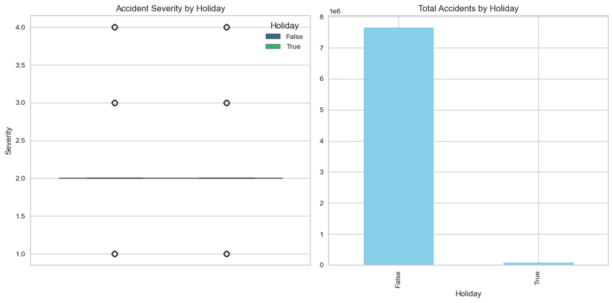

| Holiday | Severity | Time_of_Impact(hr) | Distance(mi) |
| --- | --- | --- | --- |
| False | 2.212 | 18.136 | 0.562 |
| True | 2.217 | 17.110 | 0.571 |

```python
reports,stats = test_results('Holiday',data)
data.groupby('Holiday')[['Severity','Time_of_Impact(hr)','Distance(mi)']].mean()
```

### Time of Day?

Hour of incident; During rush hours; & Night vs Day

```python
if _SPARK_:
    spark = SparkSession.builder.appName("Accident Data Project").getOrCreate()
    data = spark.read.csv('AccidentData_Clean.csv',header=True,inferSchema=True)
else:
    if _LITE_SWITCH_:
        data = pd.read_csv('AccidentData_Sampled_Clean.csv')
    else:
        tgt_cols = ['Hour','Morning_Rush','Evening_Rush','Rush_Hour','Sunrise_Sunset']
        data = pd.read_csv('AccidentData_Clean.csv',usecols = tgt_cols+['Severity','Distance(mi)','Time_of_Impact(hr)'])
```

#### Hourly

```
Based on the ANOVA test's p-value of 0.0, we reject the null hypothesis that there is no significant difference in incident time across different Hours.
Based on the ANOVA test's p-value of 0.0, we reject the null hypothesis that there is no significant difference in incident distance across different Hours.
Based on the CHI-Squared test's p-value of 0.0, we reject the null hypothesis that there is no significant difference in incident severity across different Hours.
```

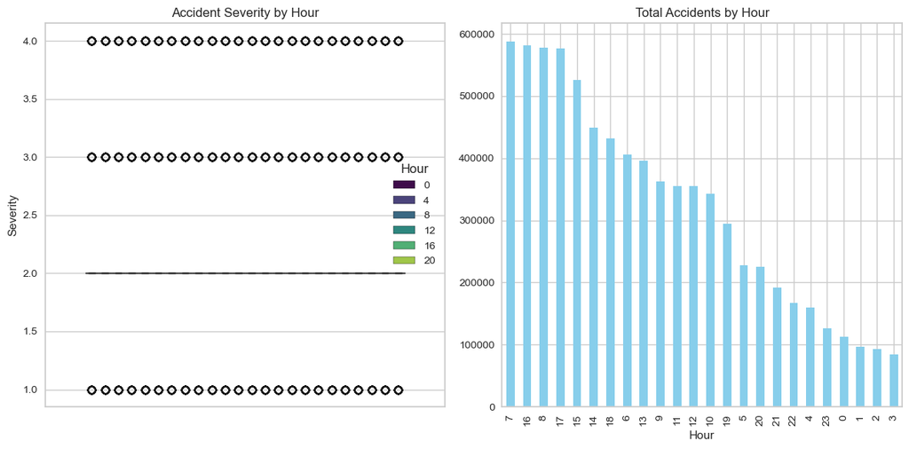

| Hour | Severity | Time_of_Impact(hr) | Distance(mi) |
| --- | --- | --- | --- |
| 0 | 2.219 | 23.884 | 0.664 |
| 1 | 2.189 | 22.234 | 0.635 |
| 2 | 2.206 | 22.718 | 0.618 |
| 3 | 2.230 | 25.617 | 0.697 |
| 4 | 2.234 | 21.981 | 0.581 |
| 5 | 2.219 | 24.256 | 0.673 |
| 6 | 2.209 | 18.814 | 0.631 |
| 7 | 2.190 | 14.873 | 0.483 |
| 8 | 2.191 | 14.340 | 0.378 |
| 9 | 2.226 | 16.542 | 0.497 |
| 10 | 2.220 | 16.943 | 0.545 |
| 11 | 2.214 | 17.701 | 0.559 |
| 12 | 2.216 | 21.574 | 0.636 |
| 13 | 2.207 | 22.811 | 0.688 |
| 14 | 2.200 | 20.590 | 0.722 |
| 15 | 2.201 | 17.813 | 0.635 |
| 16 | 2.205 | 16.441 | 0.538 |
| 17 | 2.210 | 15.963 | 0.492 |
| 18 | 2.228 | 16.406 | 0.455 |
| 19 | 2.237 | 16.727 | 0.483 |
| 20 | 2.247 | 17.397 | 0.558 |
| 21 | 2.242 | 17.857 | 0.608 |
| 22 | 2.241 | 18.596 | 0.609 |
| 23 | 2.204 | 20.719 | 0.656 |

```python
reports,stats = test_results('Hour',data)
data.groupby('Hour')[['Severity','Time_of_Impact(hr)','Distance(mi)']].mean()
```

#### Rush Hour

```
Based on the ANOVA test's p-value of 0.0, we reject the null hypothesis that there is no significant difference in incident time across different Evening_Rushs.
Based on the ANOVA test's p-value of 5.028583591285912e-264, we reject the null hypothesis that there is no significant difference in incident distance across different Evening_Rushs.
Based on the CHI-Squared test's p-value of 0.0, we reject the null hypothesis that there is no significant difference in incident severity across different Evening_Rushs.
```

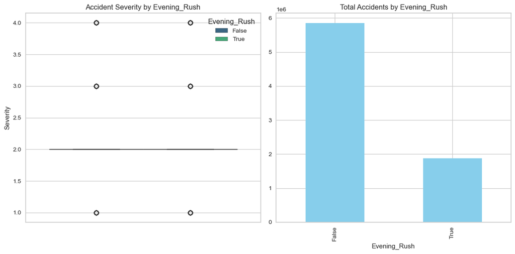

| Evening_Rush | Severity | Time_of_Impact(hr) | Distance(mi) |
| --- | --- | --- | --- |
| False | 2.213 | 18.605 | 0.574 |
| True | 2.211 | 16.635 | 0.523 |

```python
reports,stats = test_results('Evening_Rush',data)
data.groupby('Evening_Rush')[['Severity','Time_of_Impact(hr)','Distance(mi)']].mean()
```

```
Based on the ANOVA test's p-value of 0.0, we reject the null hypothesis that there is no significant difference in incident time across different Morning_Rushs.
Based on the ANOVA test's p-value of 0.0, we reject the null hypothesis that there is no significant difference in incident distance across different Morning_Rushs.
Based on the CHI-Squared test's p-value of 0.0, we reject the null hypothesis that there is no significant difference in incident severity across different Morning_Rushs.
```

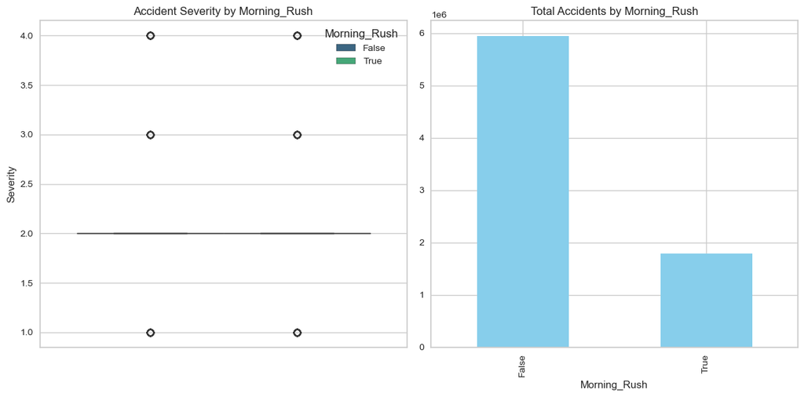

| Morning_Rush | Severity | Time_of_Impact(hr) | Distance(mi) |
| --- | --- | --- | --- |
| False | 2.216 | 18.778 | 0.582 |
| True | 2.200 | 15.960 | 0.496 |

```python
reports,stats = test_results('Morning_Rush',data)
data.groupby('Morning_Rush')[['Severity','Time_of_Impact(hr)','Distance(mi)']].mean()
```

```
Based on the ANOVA test's p-value of 0.0, we reject the null hypothesis that there is no significant difference in incident time across different Rush_Hours.
Based on the ANOVA test's p-value of 0.0, we reject the null hypothesis that there is no significant difference in incident distance across different Rush_Hours.
Based on the CHI-Squared test's p-value of 0.0, we reject the null hypothesis that there is no significant difference in incident severity across different Rush_Hours.
```

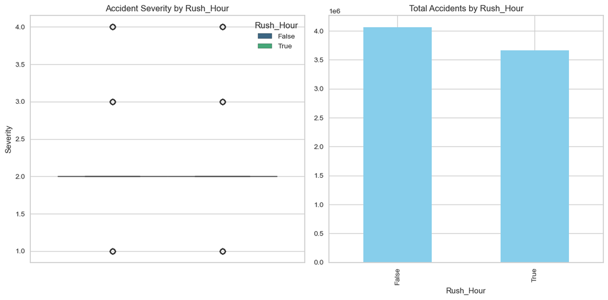

| Rush_Hour | Severity | Time_of_Impact(hr) | Distance(mi) |
| --- | --- | --- | --- |
| False | 2.218 | 19.769 | 0.609 |
| True | 2.206 | 16.306 | 0.510 |

```python
reports,stats = test_results('Rush_Hour',data)
data.groupby('Rush_Hour')[['Severity','Time_of_Impact(hr)','Distance(mi)']].mean()
```

#### Day/Night

```
Based on the ANOVA test's p-value of 0.0, we reject the null hypothesis that there is no significant difference in incident time across different Sunrise_Sunsets.
Based on the ANOVA test's p-value of 3.342799528281601e-290, we reject the null hypothesis that there is no significant difference in incident distance across different Sunrise_Sunsets.
Based on the CHI-Squared test's p-value of 0.0, we reject the null hypothesis that there is no significant difference in incident severity across different Sunrise_Sunsets.
```

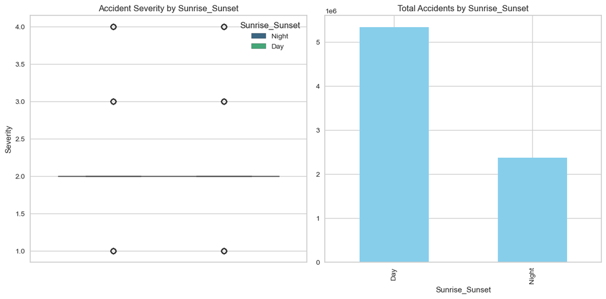

| Sunrise_Sunset | Severity | Time_of_Impact(hr) | Distance(mi) |
| --- | --- | --- | --- |
| Day | 2.209 | 17.440 | 0.544 |
| Night | 2.219 | 19.640 | 0.595 |

```python
reports,stats = test_results('Sunrise_Sunset',data)
data.groupby('Sunrise_Sunset')[['Severity','Time_of_Impact(hr)','Distance(mi)']].mean()
```

## Location Related

```python
if _LITE_SWITCH_:
    pass
elif _SPARK_:
    pass
else:
    try:
        del data
        del reports, stats
    except:
        pass
```

```python
if _SPARK_:
    spark = SparkSession.builder.appName("Accident Data Project").getOrCreate()
    data = spark.read.csv('AccidentData_Clean.csv',header=True,inferSchema=True)
else:
    if _LITE_SWITCH_:
        data = pd.read_csv('AccidentData_Sampled_Clean.csv')
    else:
        tgt_cols = ['State']
        data = pd.read_csv('AccidentData_Clean.csv',usecols = tgt_cols + ['Severity','Distance(mi)','Time_of_Impact(hr)'])
```

### By State

```python
states = data['State'].unique()

for state in states:
    print(state + ':')
    data['inState'] = data['State'] == state
    test_results('inState',data,visuals=False)
    print('-'*75)
```

```
OH:
Based on the ANOVA test's p-value of 2.298689260607847e-293, we reject the null hypothesis that there is no significant difference in incident time across different inStates.
Based on the ANOVA test's p-value of 0.23769118405886924, we fail to reject the null hypothesis that there is no significant difference in incident distance across different inStates.
Based on the CHI-Squared test's p-value of 0.0, we reject the null hypothesis that there is no significant difference in incident severity across different inStates.
---------------------------------------------------------------------------
WV:
Based on the ANOVA test's p-value of 0.0, we reject the null hypothesis that there is no significant difference in incident time across different inStates.
Based on the ANOVA test's p-value of 0.0, we reject the null hypothesis that there is no significant difference in incident distance across different inStates.
Based on the CHI-Squared test's p-value of 0.0, we reject the null hypothesis that there is no significant difference in incident severity across different inStates.
---------------------------------------------------------------------------
CA:
Based on the ANOVA test's p-value of 2.614826479459014e-191, we reject the null hypothesis that there is no significant difference in incident time across different inStates.
Based on the ANOVA test's p-value of 0.0, we reject the null hypothesis that there is no significant difference in incident distance across different inStates.
Based on the CHI-Squared test's p-value of 0.0, we reject the null hypothesis that there is no significant difference in incident severity across different inStates.
---------------------------------------------------------------------------
FL:
Based on the ANOVA test's p-value of 0.0, we reject the null hypothesis that there is no significant difference in incident time across different inStates.
Based on the ANOVA test's p-value of 7.033365495179943e-64, we reject the null hypothesis that there is no significant difference in incident distance across different inStates.
Based on the CHI-Squared test's p-value of 0.0, we reject the null hypothesis that there is no significant difference in incident severity across different inStates.
---------------------------------------------------------------------------
GA:
Based on the ANOVA test's p-value of 0.0, we reject the null hypothesis that there is no significant difference in incident time across different inStates.
Based on the ANOVA test's p-value of 1.2563274805038967e-52, we reject the null hypothesis that there is no significant difference in incident distance across different inStates.
Based on the CHI-Squared test's p-value of 0.0, we reject the null hypothesis that there is no significant difference in incident severity across different inStates.
---------------------------------------------------------------------------
SC:
Based on the ANOVA test's p-value of 0.0, we reject the null hypothesis that there is no significant difference in incident time across different inStates.
Based on the ANOVA test's p-value of 0.0, we reject the null hypothesis that there is no significant difference in incident distance across different inStates.
Based on the CHI-Squared test's p-value of 0.0, we reject the null hypothesis that there is no significant difference in incident severity across different inStates.
---------------------------------------------------------------------------
NE:
Based on the ANOVA test's p-value of 0.0, we reject the null hypothesis that there is no significant difference in incident time across different inStates.
Based on the ANOVA test's p-value of 8.843398110273978e-93, we reject the null hypothesis that there is no significant difference in incident distance across different inStates.
Based on the CHI-Squared test's p-value of 8.690172877634953e-64, we reject the null hypothesis that there is no significant difference in incident severity across different inStates.
---------------------------------------------------------------------------
IA:
Based on the ANOVA test's p-value of 2.606144786562245e-07, we reject the null hypothesis that there is no significant difference in incident time across different inStates.
Based on the ANOVA test's p-value of 0.0, we reject the null hypothesis that there is no significant difference in incident distance across different inStates.
Based on the CHI-Squared test's p-value of 0.0, we reject the null hypothesis that there is no significant difference in incident severity across different inStates.
---------------------------------------------------------------------------
```

[output cut: 190 more lines]

```
ND:
Based on the ANOVA test's p-value of 0.21840962154001944, we fail to reject the null hypothesis that there is no significant difference in incident time across different inStates.
Based on the ANOVA test's p-value of 0.0, we reject the null hypothesis that there is no significant difference in incident distance across different inStates.
Based on the CHI-Squared test's p-value of 4.2563799799208084e-176, we reject the null hypothesis that there is no significant difference in incident severity across different inStates.
---------------------------------------------------------------------------
MT:
Based on the ANOVA test's p-value of 3.2949860570468954e-98, we reject the null hypothesis that there is no significant difference in incident time across different inStates.
Based on the ANOVA test's p-value of 0.0, we reject the null hypothesis that there is no significant difference in incident distance across different inStates.
Based on the CHI-Squared test's p-value of 0.0, we reject the null hypothesis that there is no significant difference in incident severity across different inStates.
---------------------------------------------------------------------------
SD:
Based on the ANOVA test's p-value of 2.5800856592562163e-99, we reject the null hypothesis that there is no significant difference in incident time across different inStates.
Based on the ANOVA test's p-value of 4.265982112018539e-93, we reject the null hypothesis that there is no significant difference in incident distance across different inStates.
Based on the CHI-Squared test's p-value of 3.046590626258855e-85, we reject the null hypothesis that there is no significant difference in incident severity across different inStates.
---------------------------------------------------------------------------
```

```python
#reports,stats = test_results('State',data,visuals=False)
data.groupby('State')[['Severity','Time_of_Impact(hr)','Distance(mi)']].mean()
```

| State | Severity | Time_of_Impact(hr) | Distance(mi) |
| --- | --- | --- | --- |
| AL | 2.243 | 14.234 | 0.477 |
| AR | 2.276 | 17.263 | 1.420 |
| AZ | 2.120 | 16.594 | 0.552 |
| CA | 2.166 | 18.539 | 0.484 |
| CO | 2.444 | 15.253 | 0.908 |
| CT | 2.347 | 21.575 | 1.123 |
| DC | 2.144 | 20.119 | 0.385 |
| DE | 2.254 | 15.432 | 0.445 |
| FL | 2.140 | 21.762 | 0.532 |
| GA | 2.507 | 16.041 | 0.627 |
| IA | 2.419 | 17.460 | 1.951 |
| ID | 2.116 | 26.682 | 1.405 |
| IL | 2.383 | 17.111 | 0.383 |
| IN | 2.398 | 17.572 | 1.038 |
| KS | 2.328 | 19.328 | 0.821 |
| KY | 2.454 | 14.381 | 0.451 |
| LA | 2.126 | 15.150 | 0.414 |
| MA | 2.294 | 10.921 | 0.244 |
| MD | 2.333 | 18.334 | 0.676 |
| ME | 2.204 | 24.927 | 0.908 |
| MI | 2.337 | 14.838 | 0.436 |
| MN | 2.162 | 17.328 | 0.821 |
| MO | 2.400 | 17.606 | 0.555 |
| MS | 2.344 | 17.327 | 0.727 |
| MT | 2.037 | 20.736 | 2.218 |
| NC | 2.134 | 18.073 | 0.300 |
| ND | 2.013 | 17.688 | 1.798 |
| NE | 2.181 | 10.742 | 0.349 |
| NH | 2.243 | 20.170 | 0.522 |
| NJ | 2.234 | 19.621 | 0.605 |
| NM | 2.372 | 17.189 | 1.332 |
| NV | 2.231 | 21.331 | 0.923 |
| NY | 2.260 | 19.431 | 0.752 |
| OH | 2.354 | 15.907 | 0.568 |
| OK | 2.077 | 10.939 | 0.077 |
| OR | 2.112 | 31.140 | 1.025 |
| PA | 2.206 | 17.133 | 0.911 |
| RI | 2.458 | 14.289 | 0.273 |
| SC | 2.111 | 13.938 | 0.306 |
| SD | 2.443 | 44.244 | 2.701 |
| TN | 2.198 | 17.074 | 0.546 |
| TX | 2.224 | 15.795 | 0.283 |
| UT | 2.182 | 17.047 | 0.779 |
| VA | 2.279 | 17.303 | 0.762 |
| VT | 2.425 | 21.455 | 1.662 |
| WA | 2.344 | 21.849 | 0.477 |
| WI | 2.474 | 19.173 | 0.588 |
| WV | 2.157 | 37.041 | 1.147 |
| WY | 2.340 | 20.749 | 3.861 |

### Infrastructure

```python
infrastructures = ['Amenity','Bump','Crossing','Give_Way',
                   'Junction','No_Exit','Railway','Roundabout',
                   'Station','Stop','Traffic_Calming','Traffic_Signal',
                   'Turning_Loop'
                   ]
```

```python
if _SPARK_:
    spark = SparkSession.builder.appName("Accident Data Project").getOrCreate()
    data = spark.read.csv('AccidentData_Clean.csv',header=True,inferSchema=True)
else:
    if _LITE_SWITCH_:
        data = pd.read_csv('AccidentData_Sampled_Clean.csv')
    else:
        data = pd.read_csv('AccidentData_Clean.csv',usecols = infrastructures + ['Severity','Distance(mi)','Time_of_Impact(hr)'])
```